# Ch. 1 Introduction — fluidpy

### 🧩 The adiabatic lapse rate — and the two ways its sign is written `C54`

*The question:* Air gets colder as you go up. Does that make the atmosphere unstable?

#### The problem in plain words

Mountain tops are cold, yet the air over them is usually stable; smog sits under inversions; thunderstorms build on hot afternoons. In climate science the **lapse-rate feedback** — how the vertical temperature profile changes as the planet warms — is one of the main feedbacks, and those papers write the lapse rate as a *positive* number for cooling with height. You need both sign habits.

#### The idea

```
z ↑      environment T(z): cools at 6.5 K/km
  |   \    a parcel lifted without heating: cools at 9.8 K/km (it expands as the pressure drops)
  |    \ \
  |     \  \          at the same height the parcel is COLDER than its surroundings
  |______\___\___ T   → denser → sinks back → STABLE, although T falls with height
```

**Stability compares two cooling rates: the environment's and a rising parcel's own.**

📝 **Note.** **A static atmosphere from one profile** `C49` — In a fluid at rest, hydrostatics $dp/dz = -\rho g$ (1.8) and the equation of state $p = p(v, T)$ (1.12) link p, ρ and T, so one profile fixes the other two: give T(z), integrate dp/dz = −pg/(RT(z)), then ρ = p/(RT). For T(z) = 288.15 K − 6.5 K/km × z, 5 km up: p = 54.0 kPa and ρ = 0.736 kg/m³ — the standard atmosphere's values (code below).

📝 **Note.** **The lapse rate in two sign conventions** `C53` — The **lapse rate** is the environment's vertical temperature gradient. **Two sign conventions are in daily use; both are shown everywhere in this section:**

| Convention | Definition | Standard troposphere | Dry adiabatic Γ_a | Stable when |
| --- | --- | --- | --- | --- |
| Kundu (this book, fluidpy code) | Γ ≡ dT/dz | −6.5 K/km | −9.8 K/km | Γ > Γ_a, e.g. −6.5 > −9.8 |
| Meteorology (climate literature) | Γ ≡ −dT/dz | +6.5 K/km | +9.8 K/km | Γ < Γ_a, e.g. 6.5 < 9.8 |

**Converting: negate the number and flip the inequality** — Γ_met = −Γ_Kundu. The physics never changes.

> 📎 **Primer — inequalities under a sign change.** `P48` · Multiplying both sides of an inequality by a negative number reverses it: a > b ⇔ −a < −b. That is exactly the move between the two lapse-rate conventions.

```python
a, b = -6.5, -9.8                  # Kundu lapse rates [K/km]: environment and dry adiabat
print(a > b, -a < -b)              # True True: "−6.5 > −9.8" and "6.5 < 9.8" say the same thing
```

```
True True
```

```python
Ga = ch01.adiabatic_lapse_rate()                                   # Eq. (1.30), perfect gas: Γa = −g/C_p (Kundu) [K/m]
Ga_met = ch01.lapse_rate_convention(Ga, "meteorology")             # the same number in the meteorology convention [K/m]
print(f"Γa = {Ga*1e3:.3f} K/km (Kundu)  =  {Ga_met*1e3:+.3f} K/km (meteorology)")   # same physics, two signs
for dTdz in (-6.5e-3, -12.0e-3, 0.0, Ga):                          # environment gradients dT/dz [K/m]
    k = ch01.lapse_rate_stability(dTdz)                             # verdict + inequality in Kundu's form
    m = ch01.lapse_rate_stability(dTdz, convention="meteorology")   # the same test written the meteorology way
    print(f"{k.verdict:9s} | Kundu: {k.text:38s} | meteorology: {m.text}")   # verdict and both inequalities
    assert k.code == m.code                                         # the verdict never depends on the convention
```

```
Γa = -9.761 K/km (Kundu)  =  +9.761 K/km (meteorology)
stable    | Kundu: stable ⇔ dT/dz > Γa: −6.5 > −9.8 K/km  | meteorology: stable ⇔ Γ < Γa: 6.5 < 9.8 K/km
unstable  | Kundu: stable ⇔ dT/dz > Γa: −12.0 < −9.8 K/km | meteorology: stable ⇔ Γ < Γa: 12.0 > 9.8 K/km
stable    | Kundu: stable ⇔ dT/dz > Γa: 0.0 > −9.8 K/km   | meteorology: stable ⇔ Γ < Γa: 0.0 < 9.8 K/km
neutral   | Kundu: stable ⇔ dT/dz > Γa: −9.8 = −9.8 K/km  | meteorology: stable ⇔ Γ < Γa: 9.8 = 9.8 K/km
```

**What does the code above do?**

1. `adiabatic_lapse_rate()` returns Γa = −g/C_p in Kundu's convention (negative for air).
2. `lapse_rate_convention` only flips the sign for the meteorology convention.
3. `lapse_rate_stability` computes the verdict once, in Kundu's convention, and writes the criterion with numbers in the requested convention; its fields `.verdict`, `.text` and `.code` (+1 stable, 0 neutral, −1 unstable) are printed.
4. The assert proves that the verdict is the same in both conventions — only the bookkeeping differs.

> 📎 **Primer — chain rule.** `P49` · If f depends on x and y and both change, $df = (\partial f/\partial x)_y\,dx + (\partial f/\partial y)_x\,dy$. Divide by dz to get the rate along a path.

```python
f2 = lambda x, y: x**2 * y                       # a function of two variables
dx_, dy_ = 1e-6, 2e-6                            # small changes of x and y at (1, 2)
print(f2(1 + dx_, 2 + dy_) - f2(1, 2))           # the actual change ≈ 6.0e-06
print(2 * 1 * 2 * dx_ + 1**2 * dy_)              # (∂f/∂x) dx + (∂f/∂y) dy = 4e-6 + 2e-6 = 6.0e-06
```

```
6.0000059995957145e-06
6e-06
```

> 📎 **Primer — Gibbs free energy.** `P50` · g ≡ h − Ts [J/kg]. We use it only as a device: combined with the Gibbs relation dh = T ds + v dp, its differential is simply dg = v dp − s dT — a state function whose changes involve only dp and dT.

```python
T_, s_, v_, ds_, dp_, dT_ = sp.symbols("T s v ds dp dT")      # symbols for a small change
dh_ = T_ * ds_ + v_ * dp_                                     # Gibbs: dh = T ds + v dp
dg_ = dh_ - (T_ * ds_ + s_ * dT_)                             # dg = dh − d(Ts) with the product rule (P38)
print(sp.expand(dg_))                                         # → dp·v − dT·s: the T ds terms cancel
```

```
-dT*s + dp*v
```

> 📎 **Primer — exact differentials and Maxwell relations.** `P51` · If dg = A dp + B dT for a smooth state function g, then A = (∂g/∂p)_T and B = (∂g/∂T)_p, and because mixed second derivatives are equal, (∂A/∂T)_p = (∂B/∂p)_T. Applied to dg = v dp − s dT this gives a **Maxwell relation**, (∂v/∂T)_p = −(∂s/∂p)_T: an entropy derivative that cannot be measured directly equals one that can.

```python
xs_, ys_ = sp.symbols("x y")                                  # two variables
f_mix = xs_**2 * sp.sin(ys_)                                  # a smooth function
print(sp.diff(f_mix, xs_, ys_) == sp.diff(f_mix, ys_, xs_))   # ∂²f/∂x∂y equals ∂²f/∂y∂x → True
```

```
True
```

#### 🧮 Derivation — The adiabatic lapse rate without perfect-gas relations (Eq. 1.30)

**What we want to show.** Find the rate at which the temperature of a parcel changes as it moves isentropically up through a fluid in hydrostatic balance — for *any* fluid, not just a perfect gas — and then read it in both lapse-rate sign conventions.

**Assumptions.** Isentropic parcel, ds = 0 (step 1) · a single-component fluid whose state is fixed by T and p (step 2) · smooth state functions, so mixed partials commute (step 7) · parcel pressure = environment pressure, and the environment is hydrostatic (step 14) · evaluated where the parcel still has the environment's density (step 14) · perfect gas only in the last step (step 16).

**The plan.**

1. Write dh for the isentropic parcel.
2. Expand dh in T and p, which brings in C_p and an unknown (∂h/∂p)_T.
3. Find (∂h/∂p)_T with the Gibbs free energy, a Maxwell relation and α.
4. Divide by dz and use hydrostatics.

**Tools we use** (each explained before this point): Gibbs relations (C35, D10) · $C_p \equiv (\partial h/\partial T)_p$ (1.14) (C30) · $\alpha \equiv -\rho^{-1}(\partial\rho/\partial T)_p$ (1.20) (C37) · two properties fix the state (C28) · hydrostatic law (C20, D05) · chain rule (P49) · partial derivative with a variable held fixed (P39) · Gibbs free energy (P50) · exact differentials and Maxwell relations (P51) · inequalities under a sign change (P48, for the result)

**We start from**

$$ T\,ds = dh - v\,dp \ \ (1.18) \text{ with } ds = 0, \qquad \dfrac{dp}{dz} = -\rho g \ \ (1.8) $$

*In words:* the parcel's entropy stays constant, and the pressure it feels is the hydrostatic pressure of its surroundings.

**Step 1 of 16 — Set ds = 0 in the second Gibbs form.**

$$ dh = v\,dp $$

- *Why we can do this:* The parcel moves without heat or friction, so its entropy is constant (T ds = 0). We use the enthalpy form because it contains dp, which hydrostatics will supply.
- *In words:* The parcel's enthalpy changes only through the pressure it meets.

**Step 2 of 16 — Expand dh in T and p.**

$$ dh = \Big(\dfrac{\partial h}{\partial T}\Big)_p dT + \Big(\dfrac{\partial h}{\partial p}\Big)_T dp $$

- *Why we can do this:* Two properties fix the state (C28), so h = h(T, p); the chain rule for a function of two variables (P49) gives its differential. We want dT to appear.
- *In words:* h changes because T changes and because p changes.

**Step 3 of 16 — Recognise C_p.**

$$ dh = C_p\,dT + \Big(\dfrac{\partial h}{\partial p}\Big)_T dp $$

- *Why we can do this:* (1.14) defines $C_p \equiv (\partial h/\partial T)_p$. One coefficient is now a known property; the other still needs work.
- *In words:* The first part is the specific heat times the temperature change.

**Step 4 of 16 — Get (∂h/∂p)_T from Gibbs at fixed T.**

$$ \Big(\dfrac{\partial h}{\partial p}\Big)_T = T\Big(\dfrac{\partial s}{\partial p}\Big)_T + v $$

- *Why we can do this:* Gibbs dh = T ds + v dp holds for any change (D10); take a change at constant T and divide by dp (P39). This trades the unknown for an entropy derivative.
- *In words:* How h depends on p at fixed T involves how s does.

**Step 5 of 16 — Introduce the Gibbs free energy.**

$$ dg = v\,dp - s\,dT,\qquad g \equiv h - Ts $$

- *Why we can do this:* dg = dh − T ds − s dT (product rule on Ts, P38) and dh = T ds + v dp; the T ds terms cancel (P50). We choose g because its natural variables are exactly p and T.
- *In words:* A helper state function whose changes involve only dp and dT.

**Step 6 of 16 — Read off the partial derivatives of g.**

$$ \Big(\dfrac{\partial g}{\partial p}\Big)_T = v,\qquad \Big(\dfrac{\partial g}{\partial T}\Big)_p = -s $$

- *Why we can do this:* Compare dg = v dp − s dT with the chain rule dg = (∂g/∂p)_T dp + (∂g/∂T)_p dT term by term (P51).
- *In words:* v and −s are the slopes of g.

**Step 7 of 16 — Equate the mixed second derivatives.**

$$ \Big(\dfrac{\partial v}{\partial T}\Big)_p = -\Big(\dfrac{\partial s}{\partial p}\Big)_T $$

- *Why we can do this:* g is a smooth state function, so ∂²g/∂T∂p = ∂²g/∂p∂T (equality of mixed partials, P51); differentiating step 6's first result in T and the second in p gives this **Maxwell relation**. It converts an entropy derivative into a measurable one.
- *In words:* How entropy changes with pressure is set by thermal expansion.

**Step 8 of 16 — Express (∂v/∂T)_p with α.**

$$ \Big(\dfrac{\partial v}{\partial T}\Big)_p = v\,\alpha $$

- *Why we can do this:* v = 1/ρ gives (∂v/∂T)_p = −(1/ρ²)(∂ρ/∂T)_p; by $\alpha \equiv -\rho^{-1}(\partial\rho/\partial T)_p$ (1.20), (∂ρ/∂T)_p = −ρα, so the result is α/ρ = vα.
- *In words:* Heating at fixed pressure swells unit mass by vα per kelvin.

**Step 9 of 16 — Insert into the Maxwell relation.**

$$ \Big(\dfrac{\partial s}{\partial p}\Big)_T = -\,v\,\alpha $$

- *Why we can do this:* Steps 7 and 8 together. The sign matters: squeezing at fixed T lowers the entropy when α > 0.
- *In words:* Entropy falls with pressure at the rate vα.

**Step 10 of 16 — Complete (∂h/∂p)_T.**

$$ \Big(\dfrac{\partial h}{\partial p}\Big)_T = v\,(1 - \alpha T) $$

- *Why we can do this:* Substitute step 9 into step 4: T(−vα) + v = v(1 − αT). The unknown coefficient is now written with measurable properties only.
- *In words:* The pressure part of dh, in measurable properties.

**Step 11 of 16 — Equate the two expressions for dh.**

$$ C_p\,dT + v(1 - \alpha T)\,dp = v\,dp $$

- *Why we can do this:* Step 3 (with step 10) and step 1 describe the same change of the same parcel, so their right-hand sides are equal.
- *In words:* Two bookkeepings of one enthalpy change.

**Step 12 of 16 — Subtract v dp from both sides.**

$$ C_p\,dT = v\,\alpha\,T\,dp $$

- *Why we can do this:* v(1 − αT)dp − v dp = −vαT dp; moving it across makes it positive. Temperature change is now tied to pressure change alone.
- *In words:* A parcel warms when compressed and cools when the pressure drops (for α > 0).

**Step 13 of 16 — Divide by dz along the parcel's path.**

$$ C_p\,\dfrac{dT_a}{dz} = v\,\alpha\,T\,\dfrac{dp}{dz} $$

- *Why we can do this:* Both sides are changes along the vertical path; dividing by dz turns them into rates per metre. The subscript a marks the adiabatic parcel.
- *In words:* Temperature rate per metre ↔ pressure rate per metre.

**Step 14 of 16 — Use hydrostatics with v = 1/ρ.**

$$ C_p\,\dfrac{dT_a}{dz} = -\,\alpha\,T\,g $$

- *Why we can do this:* The parcel's pressure is the environment's, $dp/dz = -\rho g$ (1.8); at the release height the parcel's v equals the environment's 1/ρ, so vρ = 1.
- *In words:* The pressure drop with height sets the cooling.

**Step 15 of 16 — Divide by C_p.**

$$ \dfrac{dT_a}{dz} \equiv \Gamma_a = -\,\dfrac{g\,\alpha\,T}{C_p} $$

- *Why we can do this:* C_p > 0, so dividing by it is allowed and changes no sign. This is (1.30), derived without any perfect-gas relation.
- *In words:* The adiabatic lapse rate of any fluid.

**Step 16 of 16 — Specialise to a perfect gas.**

$$ \Gamma_a = -\,\dfrac{g}{C_p} = -9.76\ \text{K/km} $$

- *Why we can do this:* $\alpha = 1/T$ for a perfect gas (1.28, C48), so αT = 1; with g = 9.807 m/s² and C_p = 1004.7 J kg⁻¹ K⁻¹ the number follows.
- *In words:* Dry air cools 9.76 K for every kilometre it rises.

**Result**

$$ \Gamma_a = \dfrac{dT_a}{dz} = -\dfrac{g\,\alpha\,T}{C_p}; \qquad \text{dry air: } \Gamma_a = -g/C_p = -9.76 \text{ K/km} $$

*In words:* **Kundu (Γ ≡ dT/dz):** Γ_a = −9.76 K/km, and the environment is stable when **Γ > Γ_a** (e.g. −6.5 > −9.76). **Meteorology (Γ ≡ −dT/dz):** Γ_a,met = +gαT/C_p = +9.76 K/km, and it is stable when **Γ < Γ_a** (6.5 < 9.76). Converting multiplies both sides by −1, which reverses the inequality (P48); the verdict is identical.

**What it means.** Γ_a is the slope a well-mixed (isentropic) layer settles to — the reference against which every observed profile is judged. A column cooling more slowly than 9.76 K/km (dT/dz > −9.76 K/km, or Γ_met < 9.76 K/km) is stable even though it cools with height. It fails for moist air (latent heat makes the saturated rate about 4–7 K/km), for large excursions where the parcel's temperature departs from the environment's (then the local rate is −(g/C_p)T_parcel/T_env), and for mixtures whose composition changes (seawater salinity). In the explainer `parcel_stability` (C55 block), the dashed adiabat's slope is exactly this number.

**Check it.** Units: m s⁻² · K⁻¹ · K / (J kg⁻¹ K⁻¹) = K/m ✓. Limits: α = 0 (a fluid that does not expand) → Γ_a = 0, no adiabatic temperature change ✓; perfect gas → −g/C_p ✓. Numbers: air −9.76 K/km; water at 283 K (α = 1.5×10⁻⁴ K⁻¹, C_p = 4190 J kg⁻¹ K⁻¹) → −0.10 K/km ✓. The sympy cell below verifies steps 7–16 for an arbitrary Gibbs free energy, and the from-scratch cell differentiates a lifted parcel's temperature and finds −g/C_p at the release height ✓.

```python
import sympy as sp                                             # symbolic algebra (primer P40)
T_g, p_g, g_g, R_g, cp_g = sp.symbols("T p g R c_p", positive=True)   # temperature, pressure, gravity, gas constant, C_p
G = sp.Function("G")(T_g, p_g)                                 # ANY smooth Gibbs free energy per unit mass g(T, p)
v_g = sp.diff(G, p_g)                                          # step 6: v = (∂g/∂p)_T
s_g = -sp.diff(G, T_g)                                         # step 6: s = −(∂g/∂T)_p
h_g = G + T_g * s_g                                            # g = h − Ts rearranged: h = g + Ts
Cp_g = sp.diff(h_g, T_g)                                       # (1.14): C_p = (∂h/∂T)_p
alpha_g = sp.diff(v_g, T_g) / v_g                              # step 8: α = (∂v/∂T)_p / v
# Slope of an isentrope. Along it s stays constant, so by the chain rule (P49)
#   ds = (∂s/∂T)_p dT + (∂s/∂p)_T dp = 0   ⇒   dT/dp = −(∂s/∂p)_T / (∂s/∂T)_p   (the "implicit-function rule")
dTdp_s = -sp.diff(s_g, p_g) / sp.diff(s_g, T_g)                # that ratio, with s written through the arbitrary G
print(sp.simplify(dTdp_s - v_g * alpha_g * T_g / Cp_g))        # 0 → step 12 (C_p dT = v α T dp) holds for any fluid
print(sp.simplify(dTdp_s * (-g_g / v_g) + g_g * alpha_g * T_g / Cp_g))   # 0 → (1.30) after dp/dz = −g/v (steps 13–15)
G_perfect = cp_g * (T_g - T_g * sp.log(T_g)) + R_g * T_g * sp.log(p_g)  # a perfect gas with constant C_p
# .subs(G, G_perfect) replaces the unknown function G by the concrete perfect-gas formula; the derivatives of G are
# then still written as unevaluated "Derivative(...)" objects, and .doit() carries them out on the concrete formula.
print(sp.simplify((-g_g * alpha_g * T_g / Cp_g).subs(G, G_perfect).doit()))   # −g/c_p → step 16
```

```
0
0
-g/c_p
```

> ⚠️ **Common confusion (traps in this derivation):** the sign of the Maxwell relation; using dh = C_p dT (true only for a perfect gas); using the parcel's v with the environment's ρ away from the release point; **negating Γ without flipping the inequality** when switching to the meteorology convention.

📝 **Note.** **The number, in both conventions** `N17` — Earth's dry air: Γ_a = −g/C_p = −9.81/1004.7 = **−9.76 K/km in Kundu's convention = +9.76 K/km in the meteorology convention** (usually quoted as 9.8 K/km). Water is hardly affected by adiabatic compression: α = 1.5×10⁻⁴ K⁻¹ and C_p = 4190 J kg⁻¹ K⁻¹ at 283 K give Γ_a = −0.10 K/km.

#### ✏️ Tiny example: is the standard troposphere stable?

Environment dT/dz = −6.5 K/km; Γ_a = −9.76 K/km.

- **Kundu:** −6.5 > −9.76 ✓ stable. **Meteorology:** Γ = +6.5, Γ_a = +9.76, and 6.5 < 9.76 ✓ stable. The margin is 3.26 K/km in both.
- Lift a parcel 1 km from 288.15 K: it cools to 278.39 K, while the environment there is 281.65 K — the parcel is 3.26 K colder, hence denser, so it sinks back.
- N² = (g/T)(dT/dz − Γ_a) = (9.81/288.15)(3.26×10⁻³) = 1.11×10⁻⁴ s⁻² → period 9.9 min.
- Over hot ground with dT/dz = −12 K/km: −12 < −9.76 (meteorology: 12 > 9.76) → unstable; at 300 K a displacement e-folds every 117 s.

```python
N2_trop = ch01.brunt_vaisala_sq_from_lapse(288.15, -6.5e-3)          # N² = (g/T)(dT/dz + g/C_p) at the ground [1/s²]
print(f"standard troposphere: N² = {N2_trop:.3e} 1/s², {ch01.stability_timescale(N2_trop)}")      # period ≈ 596 s
print(f"parcel 1 km up: {ch01.parcel_temperature(288.15, 1000.0):.2f} K; environment {288.15 - 6.5:.2f} K")   # parcel colder than environment → sinks
N2_hot = ch01.brunt_vaisala_sq_from_lapse(300.0, -12e-3)             # superadiabatic layer over hot ground
print(f"hot ground: N² = {N2_hot:.3e} 1/s², {ch01.stability_timescale(N2_hot)}")                  # e-folds in ≈ 117 s
print(f"water: Γa = {ch01.adiabatic_lapse_rate(T=283.15, cp=4190.0, alpha=1.5e-4)*1e3:.3f} K/km")   # (1.30) general form
z5 = np.array([0.0, 5000.0])                                          # the ground and 5 km [m]
p5, rho5, T5 = ch01.atmosphere_from_temperature(z5, lambda zz: 288.15 - 6.5e-3 * zz)   # C49: p, ρ, T from T(z) alone
print(f"C49 at 5 km: p = {p5[-1]/1e3:.1f} kPa, ρ = {rho5[-1]:.3f} kg/m³; USSA-1976: {ch01.standard_atmosphere(5000.0)[1]/1e3:.1f} kPa")   # matches the standard atmosphere
```

```
standard troposphere: N² = 1.110e-04 1/s², ('period', 596.444997659674)
parcel 1 km up: 278.39 K; environment 281.65 K
hot ground: N² = -7.320e-05 1/s², ('efold', 116.88224575403171)
water: Γa = -0.099 K/km
C49 at 5 km: p = 54.0 kPa, ρ = 0.736 kg/m³; USSA-1976: 54.0 kPa
```

**What does the code above do?**

1. `brunt_vaisala_sq_from_lapse` is N² in lapse-rate form (derived as D36 in the next block); `stability_timescale` turns it into a period or an e-folding time.
2. `parcel_temperature` follows the dry adiabat from the ground, T₀ + Γ_a z.
3. `adiabatic_lapse_rate` with α and C_p given uses the general form $\Gamma_a = -g\alpha T/C_p$ (1.30) — for water.
4. `atmosphere_from_temperature` integrates hydrostatics with p = ρRT for a given T(z): one profile fixes the other two (C49).

#### From scratch: lift a parcel and measure its slope

Take the standard atmosphere's pressure profile, lift a dry parcel from the ground along the isentrope $T/T_0 = (p/p_0)^{(\gamma-1)/\gamma}$ (1.26), and differentiate its temperature numerically.

```python
z_lift = np.linspace(0, 200, 201)                                     # heights every metre up to 200 m [m]
T_env, p_env, _ = ch01.standard_atmosphere(z_lift)                    # the environment the parcel rises through (USSA-1976)
T_parcel = 288.15 * (p_env / p_env[0])**((ch01.GAMMA_AIR - 1) / ch01.GAMMA_AIR)   # (1.26): its own temperature at each height
dTdz_parcel = np.gradient(T_parcel, z_lift, edge_order=2)             # its slope dT/dz along the path (P22) [K/m]
assert np.isclose(dTdz_parcel[0], ch01.adiabatic_lapse_rate(), rtol=1e-3)   # = Γa = −g/C_p at the release height (Kundu)
assert np.isclose(-dTdz_parcel[0], ch01.lapse_rate_convention(ch01.adiabatic_lapse_rate(), "meteorology"), rtol=1e-3)  # = +g/C_p
print(f"parcel slope at release: {dTdz_parcel[0]*1e3:.3f} K/km (Kundu) = {-dTdz_parcel[0]*1e3:+.3f} K/km (meteorology)")   # both conventions
```

```
parcel slope at release: -9.761 K/km (Kundu) = +9.761 K/km (meteorology)
```

At the release height parcel and environment coincide, so the slope is exactly $\Gamma_a = -g\alpha T/C_p$ (1.30), which is $-g/C_p$ for a perfect gas. Higher up the parcel is colder than the air around it and its slope becomes −(g/C_p)(T_parcel/T_env) — $\Gamma_a = -g/C_p$ (1.30) is the *local* rate where the two still match, the point step 14 of D19 makes.

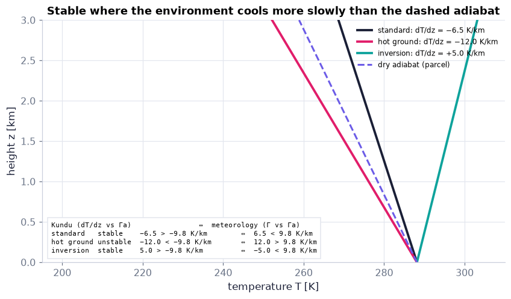

```python
z_km = np.linspace(0, 3, 61)                                                 # heights [km]
fig, ax = plt.subplots(figsize=(7.6, 4.4))                                   # one panel: temperature across, height up
rows = []                                                                    # text rows for the side table
for dTdz_km, col, name in ((-6.5, COLORS["ink"], "standard"), (-12.0, COLORS["rose"], "hot ground"), (5.0, COLORS["teal"], "inversion")):  # 3 profiles
    ax.plot(288.15 + dTdz_km * z_km, z_km, color=col, lw=2.5, label=f"{name}: dT/dz = {dTdz_km:+.1f} K/km".replace("-", "−"))  # T(z)
    k = ch01.lapse_rate_stability(dTdz_km * 1e-3, prefix=False)              # Kundu: verdict and bare inequality
    m = ch01.lapse_rate_stability(dTdz_km * 1e-3, convention="meteorology", prefix=False)   # meteorology form
    rows.append(f"{name:10s} {k.verdict:8s}  {k.text:22s}  ⇔  {m.text}")    # one row of the table
ax.plot(ch01.parcel_temperature(288.15, z_km * 1e3), z_km, "--", color=COLORS["accent"], lw=2, label="dry adiabat (parcel)")  # Γa line
ax.text(0.02, 0.03, "Kundu (dT/dz vs Γa)                ⇔  meteorology (Γ vs Γa)\n" + "\n".join(rows),   # header + rows
        transform=ax.transAxes, fontsize=7.5, family="monospace", va="bottom",   # placed in axes coordinates, fixed-width font
        bbox=dict(facecolor="white", edgecolor=COLORS["grid"]))              # the convention table inside the axes
ax.set_xlabel("temperature T [K]"); ax.set_ylabel("height z [km]")          # axis labels with units
ax.set_ylim(0, 3); ax.set_xlim(195, 310)                                    # room on the left for the table
ax.set_title("Stable where the environment cools more slowly than the dashed adiabat")   # the message
ax.legend(loc="upper right", fontsize=8)                                      # legend
savefig(fig, "ch01", "c54_lapse_rates")                                       # keep a copy for review
plt.show()                                                                    # display
```

**What you see.** Three environment profiles starting at 288.15 K — black (cooling 6.5 K/km), rose (cooling 12 K/km) and teal (warming 5 K/km, an inversion) — and one dashed purple dry adiabat. The box lists each profile's verdict with its inequality written both ways.

**How to read it.** Where an environment line leans *less* than the dashed adiabat (cools more slowly), a lifted parcel ends up colder than its surroundings → stable; where it leans *more*, the parcel ends up warmer → unstable. In the box, each Kundu inequality and its meteorology twin always give the same verdict.

**What would change if…** Make the environment cool at exactly 9.76 K/km and its line lies on top of the adiabat: neutral — a parcel is at home at every height, and both inequalities become equalities.

```python
z3 = np.linspace(0, 3e3, 61)                                                   # heights [m]
grads = np.linspace(-15e-3, 10e-3, 26)                                         # environment dT/dz from −15 to +10 K/km [K/m]
def column(dTdz):                                                              # one slider position
    return {"environment T(z)": (288.15 + dTdz * z3, z3 / 1e3),   # environment line [K, km]
            "dry adiabat": (ch01.parcel_temperature(288.15, z3), z3 / 1e3)}   # the parcel's line, fixed
fig = slider_figure(column, "dT/dz", grads * 1e3, unit="K/km", xlabel="temperature T [K]", ylabel="height z [km]",   # 26 slider positions
                    title="", active=int(np.argmin(np.abs(grads + 6.5e-3))))   # start at −6.5 K/km
for i, x in enumerate(grads):                                                  # per-position title with both conventions
    k = ch01.lapse_rate_stability(x, prefix=False)                             # Kundu form
    m = ch01.lapse_rate_stability(x, convention="meteorology", prefix=False)   # meteorology form
    kind, secs = ch01.stability_timescale(ch01.brunt_vaisala_sq_from_lapse(288.15, x))   # period or e-folding time
    extra = {"period": f"period {secs/60:.1f} min", "efold": f"e-folds in {secs:.0f} s", "none": "no restoring force"}[kind]   # time-scale text
    st = fig.layout.sliders[0].steps[i]                                        # the slider step (method "update")
    st.args = [st.args[0], {"title.text": f"dT/dz: {k.text}  ⇔  Γ_met: {m.text}: <b>{k.verdict}</b>, {extra}"}]   # this position's title
fig.layout.title.text = fig.layout.sliders[0].steps[fig.layout.sliders[0].active].args[1]["title.text"]   # starting title
fig.show()                                                                     # drag the lapse rate
```

[interactive chart not shown]

**What does the code above do?**

1. For each environment gradient from −15 to +10 K/km the figure shows the environment line and the fixed dry adiabat.
2. `lapse_rate_stability` writes the criterion in Kundu's form and in the meteorology form; the two texts are joined with ⇔ in each slider position's title (the step's second dictionary updates the layout, as in the C20 slider).
3. `brunt_vaisala_sq_from_lapse` and `stability_timescale` add the period or the e-folding time.

**What you see.** An environment temperature line and the fixed dashed dry adiabat, both starting at 288.15 K at the ground; the title states the criterion in both conventions, the verdict and the time scale.

**How to read it.** If the environment line leans less than the adiabat (cools more slowly), a lifted parcel is colder than its surroundings: stable, and the title gives an oscillation period. If it leans more, the title gives an e-folding time.

**What would change if…** Put the slider on −10 K/km, just steeper than Γa: the verdict turns unstable, the Kundu inequality reads −10.0 < −9.8 and the meteorology one 10.0 > 9.8 — both flip together.

**What would change if…** you read a paper saying "the lapse rate increases under warming"? In its convention Γ = −dT/dz grows, i.e. the air cools *faster* with height and moves *toward* Γ_a — it becomes less stable. In our code that is dT/dz becoming more negative. **Next:** a temperature label that removes the parcel's own cooling altogether (C55).

### 🧩 Potential temperature θ: a temperature label that survives lifting `C55`

*The question:* Can we label a parcel of air with a temperature that does not change when it rises or sinks without heating?

#### The problem in plain words

Is air at 500 hPa and −23 °C "colder" than surface air at 15 °C? Bring it down and it warms by compression. Weather maps, isentropic analysis and all of dry atmospheric dynamics (Ch. 13) use a temperature with that effect removed.

#### The idea

Bring every parcel adiabatically to a reference pressure p_o and read its thermometer there.

**Which p_o?** The book takes p_o = p(0), the sea-level pressure, close to 100 kPa. Meteorology — and fluidpy's `potential_temperature` (`P_REF`) — fixes it at exactly 1000 hPa = 100 kPa. The two differ by about 1 % at sea level (1013 vs 1000 hPa), which is why the code below finds θ ≈ 287.1 K rather than 288.15 K at the ground. What matters is that p_o is **one fixed constant** for every parcel; fluidpy keeps it (`p_ref`) separate from the statics pressure `p0`, the pressure at z = 0 of a particular column, which can vary from day to day.

```
500 hPa    T = 250 K  ──(compress adiabatically down to 1000 hPa)──►  θ = 305 K
1000 hPa   T = 288 K  ──(already there)────────────────────────────►  θ = 288 K
θ increases upward  ⇒  a lifted parcel is always cooler (in θ) than the air above it  ⇒  stable
```

The tools: the exponent rules (P43, C06 block) and the isentropic ratio $T/T_0 = (p/p_0)^{(\gamma-1)/\gamma}$ (1.26) (C46, C45 block).

#### 🧮 Derivation — Potential temperature (Eq. 1.31)

**What we want to show.** Define a temperature label that a parcel keeps when it moves up or down without heating: the temperature it would have if brought adiabatically to a standard pressure p_o.

**Assumptions.** Perfect gas with constant γ (start) · the imagined trip to p_o is adiabatic and reversible (step 1) · p_o is one fixed reference pressure for all parcels (step 1): sea-level pressure ≈ 100 kPa in the book, exactly 1000 hPa in meteorology and in fluidpy.

**The plan.**

1. Choose the two states as 'now' and 'at the reference pressure'.
2. Solve for the reference temperature.
3. Rewrite the exponent with R/C_p.

**Tools we use** (each explained before this point): isentropic ratios (C46, C45) · exponent rules (P43) · R = C_p − C_v and γ = C_p/C_v (C42, C43)

**We start from**

$$ \dfrac{T}{T_0} = \Big(\dfrac{p}{p_0}\Big)^{(\gamma-1)/\gamma} $$

*In words:* along one isentrope of a perfect gas, the temperature ratio of any two states is a power of their pressure ratio (1.26).

**Step 1 of 5 — Take the reference state (θ, p_o) and the current state (T, p).**

$$ \dfrac{T}{\theta} = \Big(\dfrac{p}{p_o}\Big)^{(\gamma-1)/\gamma} $$

- *Why we can do this:* $T/T_0 = (p/p_0)^{(\gamma-1)/\gamma}$ (1.26) links any two states on one isentrope; by definition the parcel taken adiabatically to p_o has the temperature θ, so rename T₀ → θ and p₀ → p_o.
- *In words:* The parcel now and the parcel at the reference pressure lie on the same isentrope.

**Step 2 of 5 — Multiply both sides by θ.**

$$ T = \theta\,\Big(\dfrac{p}{p_o}\Big)^{(\gamma-1)/\gamma} $$

- *Why we can do this:* θ ≠ 0, so multiplying both sides by it keeps the equation true; this is the book's form (1.31).
- *In words:* Actual temperature = potential temperature scaled by a pressure factor.

**Step 3 of 5 — Solve for θ.**

$$ \theta = T\,\Big(\dfrac{p_o}{p}\Big)^{(\gamma-1)/\gamma} $$

- *Why we can do this:* Divide both sides by the power and use 1/(a/b)^k = (b/a)^k (P43). This is the form we compute.
- *In words:* Correct the thermometer reading for the pressure.

**Step 4 of 5 — Rewrite the exponent with C_v and C_p.**

$$ \dfrac{\gamma-1}{\gamma} = 1 - \dfrac{C_v}{C_p} $$

- *Why we can do this:* Split the fraction: (γ − 1)/γ = 1 − 1/γ, and 1/γ = C_v/C_p by $\gamma \equiv C_p/C_v$ (1.24).
- *In words:* The exponent is one minus the inverse of the specific-heat ratio.

**Step 5 of 5 — Use R = C_p − C_v.**

$$ \theta = T\,\Big(\dfrac{p_o}{p}\Big)^{R/C_p} $$

- *Why we can do this:* 1 − C_v/C_p = (C_p − C_v)/C_p = R/C_p by $R = C_p - C_v$ (1.23); for air R/C_p = 287.06/1004.7 = 2/7.
- *In words:* The form used in meteorology, with exponent 0.286.

**Result**

$$ T = \theta\,(p/p_o)^{(\gamma-1)/\gamma} \ \ (1.31), \qquad \theta = T\,(p_o/p)^{R/C_p} $$

*In words:* potential temperature is the temperature a parcel would have at the reference pressure p_o (1000 hPa in fluidpy).

**What it means.** θ is the conserved temperature of dry adiabatic motion: two parcels can be compared regardless of their heights. Its vertical gradient is the stability test (C57, D36). It changes when heat is added (radiation, condensation) — which is how diabatic heating is measured.

**Check it.** The exponent is dimensionless and so is p_o/p ✓. At p = p_o, θ = T ✓. Adiabatic motion keeps θ constant, because it only moves the parcel along its isentrope ✓. Number: 500 hPa, 250 K → θ = 250 × 2^(2/7) = 304.8 K ✓ (`potential_temperature(250.0, 5e4)` and the from-scratch formula below agree).

> ⚠️ **Common confusion (traps in this derivation):** p_o is a fixed constant — do not use the local pressure p, or a surface pressure that varies from place to place, in its place (fluidpy keeps `p_ref` separate from the statics `p0` for this reason); inverting the ratio (p/p_o instead of p_o/p) in the computed form.

#### ✏️ Tiny example: two parcels

θ = T(p_o/p)^(R/C_p) with R/C_p = 287.06/1004.7 = 0.2857 = 2/7.

- A parcel at 500 hPa and 250 K: θ = 250 × 2^0.2857 = 250 × 1.2190 = 304.8 K.
- Surface air at 1000 hPa and 288 K: θ = 288 K.
- The upper parcel is 38 K colder in T but 17 K warmer in θ — the column is stable.

```python
print(f"θ(250 K, 500 hPa) = {ch01.potential_temperature(250.0, 5.0e4):.2f} K")        # Eq. (1.31) → 304.75 K
z_tr = np.linspace(0, 11e3, 111)                                                        # the troposphere, every 100 m [m]
T_tr, p_tr, rho_tr = ch01.standard_atmosphere(z_tr)                                     # USSA-1976 (geopotential height)
theta_tr = ch01.potential_temperature(T_tr, p_tr)                                       # θ at every height [K] (p_o = 1000 hPa)
dth = np.gradient(theta_tr, z_tr, edge_order=2)                                          # dθ/dz [K/m] (P22)
N2_theta = ch01.brunt_vaisala_sq_from_theta(theta_tr, dth)                               # N² = (g/θ) dθ/dz (D36 result)
N2_lapse = ch01.brunt_vaisala_sq_from_lapse(T_tr, -6.5e-3)                               # N² = (g/T)(dT/dz + g/C_p)
assert np.allclose(N2_theta, N2_lapse, rtol=1e-3)                                        # two forms of the same N²
print(f"θ rises from {theta_tr[0]:.2f} K at the ground to {theta_tr[-1]:.1f} K at 11 km")   # stable: θ increases upward
print(f"N² at the ground: from θ {N2_theta[0]:.4e}, from the lapse rate {N2_lapse[0]:.4e} 1/s²")   # the two forms agree
print(f"C56 dθ/dz at the ground: {ch01.potential_temperature_gradient(T_tr[0], -6.5e-3, p=p_tr[0])*1e3:.2f} K/km")   # (1.32)
```

```
θ(250 K, 500 hPa) = 304.75 K
θ rises from 287.07 K at the ground to 331.2 K at 11 km
N² at the ground: from θ 1.1097e-04, from the lapse rate 1.1097e-04 1/s²
C56 dθ/dz at the ground: 3.25 K/km
```

**What does the code above do?**

1. `potential_temperature` is $T = \theta\,(p/p_o)^{(\gamma-1)/\gamma}$ (1.31) with p_o = 1000 hPa — note θ at the ground is about 287.1 K, not 288.15 K, because the standard ground pressure 1013 hPa is slightly above the reference pressure (see "Which p_o?" above).
2. θ increases steadily through the standard troposphere: it is stable everywhere.
3. N² from the θ gradient (`brunt_vaisala_sq_from_theta`) and from the lapse rate (`brunt_vaisala_sq_from_lapse`) agree — the result of D36 below, checked on real profiles.
4. `potential_temperature_gradient` is $\frac{T}{\theta}\frac{d\theta}{dz} = \frac{dT}{dz} + \frac{g}{C_p}$ (1.32), i.e. dθ/dz = (θ/T)(dT/dz + g/C_p).

#### From scratch: θ by the formula

```python
theta_mine = T_tr * (ch01.P_REF / p_tr)**((ch01.GAMMA_AIR - 1) / ch01.GAMMA_AIR)   # θ = T (p_o/p)^((γ−1)/γ), D20 step 3
assert np.allclose(theta_mine, ch01.potential_temperature(T_tr, p_tr))              # = the library
assert np.allclose(ch01.temperature_from_potential(theta_mine, p_tr), T_tr)         # and back again (D20 step 2)
print(f"θ at 5 km: {theta_mine[50]:.2f} K (mine) = {ch01.potential_temperature(T_tr[50], p_tr[50]):.2f} K (library)")   # one sample value
```

```
θ at 5 km: 304.83 K (mine) = 304.83 K (library)
```

📝 **Note.** **θ's gradient and the two lapse rates** `C56` — Taking logarithms of $T = \theta\,(p/p_o)^{(\gamma-1)/\gamma}$ (1.31), differentiating in z, and using dp/dz = −ρg, p = ρRT and α = 1/T gives (stated) the link between θ's gradient and the two lapse rates, written here in both conventions. Standard troposphere at the ground: (θ/T)(−6.5 + 9.76) K/km = 3.25 K/km.

$$ \frac{T}{\theta}\frac{d\theta}{dz} = \frac{dT}{dz} + \frac{g}{C_p} = \Gamma - \Gamma_a\ \text{(Kundu)} = \Gamma_{a,\rm met} - \Gamma_{\rm met}\ \text{(meteorology)} \qquad \text{(1.32)} $$

📝 **Note.** **The log-derivative of (1.31)** `N19` — The logarithmic derivative of $T = \theta\,(p/p_o)^{(\gamma-1)/\gamma}$ (1.31), $\frac{1}{T}\frac{dT}{dz} = \frac{1}{\theta}\frac{d\theta}{dz} + \frac{\gamma-1}{\gamma p}\frac{dp}{dz}$, is step 5 of the next derivation; the same move gives the atmosphere's θ profiles in Ch. 13 §13.2.

> 📎 **Primer — logarithmic differentiation.** `P52` · d(ln f)/dz = (1/f) df/dz, and logarithms turn products and powers into sums: ln(ab^k) = ln a + k ln b. So the relative rate of change of a product of powers is the weighted sum of the relative rates of its factors.

```python
zq, hq = 2.0, 1e-6                                                 # a point and a small step
print((np.log((zq + hq)**3) - np.log(zq**3)) / hq, 3 / zq)          # d ln(z³)/dz = 3/z = 1.5 at z = 2
```

```
1.4999996253983738 1.5
```

#### 🧮 Derivation — N² from the potential-temperature gradient (links Eqs. 1.29 and 1.32; our addition)

**What we want to show.** Show that for a perfect-gas atmosphere the density-based $N^2 = -\frac{g}{\rho}\big(\frac{d\rho}{dz} - \frac{d\rho_a}{dz}\big)$ (1.29) is simply g/θ times the vertical gradient of θ — so stability means "θ increases upward" — and connect it to the two lapse rates.

**Assumptions.** Perfect gas with constant γ (steps 2–3) · the parcel's pressure equals the environment's (step 3) · at the parcel's rest height ρ_a = ρ (step 1).

**The plan.**

1. Write both density gradients as relative (logarithmic) rates.
2. Environment from p = ρRT; parcel from the isentropic ratio.
3. Subtract: the pressure terms combine into θ.
4. Use $\frac{T}{\theta}\frac{d\theta}{dz} = \frac{dT}{dz} + \frac{g}{C_p}$ (1.32) for the lapse-rate form.

**Tools we use** (each explained before this point): $N^2 = -\frac{g}{\rho}\big(\frac{d\rho}{dz} - \frac{d\rho_a}{dz}\big)$ (1.29) (C51, D18) · logarithmic differentiation (P52) · p = ρRT (C40) · isentropic ratios $\rho/\rho_0 = (p/p_0)^{1/\gamma}$ (1.26) (C46) · θ, $T = \theta\,(p/p_o)^{(\gamma-1)/\gamma}$ (1.31) (D20) · $\frac{T}{\theta}\frac{d\theta}{dz} = \frac{dT}{dz} + \frac{g}{C_p}$ (1.32) (C56) · γ and R/C_p (C42, C43)

**We start from**

$$ N^2 = -\dfrac{g}{\rho}\Big(\dfrac{d\rho}{dz} - \dfrac{d\rho_a}{dz}\Big) $$

*In words:* the parcel result (1.29) of D18, evaluated at the height where parcel and environment share the density ρ.

**Step 1 of 8 — Take ρ inside the bracket.**

$$ N^2 = -g\Big(\dfrac1\rho\dfrac{d\rho}{dz} - \dfrac1\rho\dfrac{d\rho_a}{dz}\Big) $$

- *Why we can do this:* Distribute 1/ρ over both terms; at the rest height the parcel's density equals ρ, so each term is a relative (logarithmic) rate. Relative rates are what logarithms make easy.
- *In words:* N² compares relative density changes.

**Step 2 of 8 — Log-differentiate the environment's p = ρRT.**

$$ \dfrac1\rho\dfrac{d\rho}{dz} = \dfrac1p\dfrac{dp}{dz} - \dfrac1T\dfrac{dT}{dz} $$

- *Why we can do this:* ρ = p/(RT), so ln ρ = ln p − ln R − ln T; differentiate in z with R constant (P52).
- *In words:* The environment's density falls because the pressure falls, and rises where it gets colder.

**Step 3 of 8 — Log-differentiate the parcel's isentropic density.**

$$ \dfrac1{\rho_a}\dfrac{d\rho_a}{dz} = \dfrac1\gamma\,\dfrac1p\dfrac{dp}{dz} $$

- *Why we can do this:* Along its isentrope $\rho_a \propto p^{1/\gamma}$ (1.26), and the parcel's pressure is the environment's p(z); so ln ρ_a = (1/γ) ln p + const.
- *In words:* The parcel's density follows the pressure only, and more weakly.

**Step 4 of 8 — Subtract step 3 from step 2.**

$$ \dfrac1\rho\dfrac{d\rho}{dz} - \dfrac1\rho\dfrac{d\rho_a}{dz} = \Big(1 - \dfrac1\gamma\Big)\dfrac1p\dfrac{dp}{dz} - \dfrac1T\dfrac{dT}{dz} $$

- *Why we can do this:* Collect the two pressure terms; ρ_a = ρ at the rest height, so the second term on the left is step 3.
- *In words:* What decides stability: a pressure part and a temperature part.

**Step 5 of 8 — Log-differentiate θ = T(p_o/p)^((γ−1)/γ).**

$$ \dfrac1\theta\dfrac{d\theta}{dz} = \dfrac1T\dfrac{dT}{dz} - \dfrac{\gamma-1}{\gamma}\,\dfrac1p\dfrac{dp}{dz} $$

- *Why we can do this:* ln θ = ln T + ((γ − 1)/γ)(ln p_o − ln p) (P52); p_o is a constant. This is the log-derivative of $T = \theta\,(p/p_o)^{(\gamma-1)/\gamma}$ (1.31) (N19).
- *In words:* θ rises with T and with falling pressure.

**Step 6 of 8 — Recognise the bracket of step 4.**

$$ \Big(1 - \dfrac1\gamma\Big)\dfrac1p\dfrac{dp}{dz} - \dfrac1T\dfrac{dT}{dz} = -\,\dfrac1\theta\dfrac{d\theta}{dz} $$

- *Why we can do this:* 1 − 1/γ = (γ − 1)/γ, so the right side of step 4 is exactly minus the right side of step 5.
- *In words:* The density race is the θ gradient in disguise.

**Step 7 of 8 — Substitute into step 1.**

$$ N^2 = \dfrac{g}{\theta}\,\dfrac{d\theta}{dz} $$

- *Why we can do this:* Steps 4 and 6 replace the bracket by −(1/θ)dθ/dz; −g × (−(1/θ)dθ/dz) — the two minus signs cancel.
- *In words:* N² is g over θ times θ's gradient.

**Step 8 of 8 — Use (1.32) for the lapse-rate form.**

$$ N^2 = \dfrac{g}{T}\Big(\dfrac{dT}{dz} + \dfrac{g}{C_p}\Big) = \dfrac{g}{T}\,(\Gamma - \Gamma_a) $$

- *Why we can do this:* $\frac{T}{\theta}\frac{d\theta}{dz} = \frac{dT}{dz} + \frac{g}{C_p}$ (1.32) gives (1/θ)dθ/dz = (1/T)(dT/dz + g/C_p) (C56); with Γ_a = −g/C_p (D19) the bracket is Γ − Γ_a in Kundu's convention.
- *In words:* N² is proportional to how much more slowly the environment cools than a parcel.

**Result**

$$ N^2 = \dfrac{g}{\theta}\dfrac{d\theta}{dz} = \dfrac{g}{T}\,(\Gamma - \Gamma_a)\ \text{(Kundu)} = \dfrac{g}{T}\,(\Gamma_{a,\rm met} - \Gamma_{\rm met})\ \text{(meteorology)} $$

*In words:* a perfect-gas atmosphere is stable exactly where θ increases upward; in lapse rates, where the environment cools more slowly than 9.76 K/km.

**What it means.** One profile — θ(z) — tells you everything about dry static stability; this is how Ch. 13 and weather analysis read soundings, and why isentropic surfaces are the natural coordinates of dry dynamics. It fails for moist air (use the equivalent potential temperature) and for the ocean, where salinity requires potential density (C61). In the explainer `parcel_stability` below, the N² computed from θ equals the N² readout computed from the lapse rate.

**Check it.** Units: (m s⁻²/K) × K/m = s⁻² ✓. Neutral: dθ/dz = 0 ⇔ Γ = Γ_a ✓. An isothermal layer (dT/dz = 0) at 250 K: N² = g²/(C_pT) = 3.83×10⁻⁴ s⁻², period 5.4 min ✓. Standard troposphere at 288.15 K: 1.11×10⁻⁴ s⁻², period 9.9 min ✓ — the code above computed N² from the θ profile of USSA-1976 with `np.gradient` and from the lapse rate, and they agree to 10⁻³.

> ⚠️ **Common confusion (traps in this derivation):** using the environment's density gradient for the parcel; forgetting (γ − 1)/γ = R/C_p when comparing with $\frac{T}{\theta}\frac{d\theta}{dz} = \frac{dT}{dz} + \frac{g}{C_p}$ (1.32); substituting dp/dz = −ρg too early (it is not needed until step 8).

📝 **Note.** **Stability from θ** `C57` — So a dry atmosphere is **stable where θ increases with height, neutral where it stays constant, unstable where it decreases** — the gradient of θ, not of T, decides. In a laboratory tank the difference hardly matters: over 1 m the adiabatic cooling is only 9.8×10⁻³ K, so T ≈ θ.

$$ N^2 = \frac{g}{\theta}\frac{d\theta}{dz} $$

📝 **Note.** **A typical lower atmosphere** `N18` — A typical lower atmosphere (our synthetic profile, not digitised from the book's figure): a **mixed layer** near the ground cooling at almost exactly Γ_a (near-neutral, stirred by turbulence), an **inversion** where T *rises* with height (very stable: smog and fog stay below it), and a **stable layer** above that cools more slowly than Γ_a. In θ: vertical in the mixed layer, a sharp increase through the inversion, a steady increase above. The slider below builds it with the mixed layer set exactly to Γ_a.

```python
z_bl = np.linspace(0, 2000, 201)                                                  # heights up to 2 km, every 10 m [m]
inv = np.linspace(-5e-3, 20e-3, 26)                                               # inversion-layer dT/dz, −5 … +20 K/km [K/m]
def boundary_layer(x_km):                                                         # one slider position (K/km)
    col = ch01.synthetic_boundary_layer_column(z_bl, inversion_dT_dz=x_km * 1e-3,   # T, p, ρ, θ, N² layer by layer …
                                               mixed_dT_dz=ch01.adiabatic_lapse_rate())   # … with the mixed layer exactly neutral
    stab = col["N2"] > 1e-12                                                      # stable where N² > 0
    return {"θ(z)": (col["theta"], z_bl / 1e3),                                   # potential temperature [K] against z [km]
            "θ where stable (N² > 0)": (np.where(stab, col["theta"], np.nan), z_bl / 1e3),   # teal markers
            "T(z)": (col["T"], z_bl / 1e3),                                       # actual temperature [K]
            "θ where neutral or unstable (N² ≤ 0)": (np.where(~stab, col["theta"], np.nan), z_bl / 1e3)}   # rose markers
fig = slider_figure(boundary_layer, "inversion dT/dz", inv * 1e3, unit="K/km", xlabel="temperature T, θ [K]",   # 26 positions
                    ylabel="height z [km]", title="", active=15,                  # start at +10 K/km
                    modes={"θ where stable (N² > 0)": "markers", "θ where neutral or unstable (N² ≤ 0)": "markers"})   # masked θ as dots
palette = {"θ(z)": COLORS["accent"], "T(z)": COLORS["ink"], "θ where stable (N² > 0)": COLORS["teal"],   # colour per trace name
           "θ where neutral or unstable (N² ≤ 0)": COLORS["rose"]}               # the colours used throughout this section
for tr in fig.data:                                                               # recolour every precomputed trace
    tr.line.color = palette[tr.name]; tr.marker.color = palette[tr.name]; tr.marker.size = 4   # line, marker colour and size
for i, x in enumerate(inv):                                                       # per-position title: N² in the inversion
    N2_inv = ch01.brunt_vaisala_sq_from_lapse(288.0, x)                            # at a typical temperature there
    kind, secs = ch01.stability_timescale(N2_inv)                                  # period or e-folding time
    k = ch01.lapse_rate_stability(x, prefix=False); m = ch01.lapse_rate_stability(x, convention="meteorology", prefix=False)  # both forms
    tail = f"period {secs/60:.1f} min" if kind == "period" else (f"e-folds in {secs:.0f} s" if kind == "efold" else "neutral")  # time scale text
    st = fig.layout.sliders[0].steps[i]                                            # the slider step (method "update")
    st.args = [st.args[0], {"title.text": f"inversion layer: {k.text} ⇔ {m.text} ({k.verdict}), N² = {N2_inv:.1e} s⁻², {tail}"}]  # its title
fig.layout.title.text = fig.layout.sliders[0].steps[15].args[1]["title.text"]    # starting title
fig.show()                                                                        # drag the inversion strength
```

[interactive chart not shown]

**What does the code above do?**

1. `synthetic_boundary_layer_column` builds T, p, ρ, θ and N² layer by layer (hydrostatics and p = ρRT) for a mixed layer at exactly Γ_a, an inversion of adjustable strength from 800 to 1000 m, and a stable layer above.
2. θ is drawn twice more as markers, masked with `np.where` (P46): teal where N² > 0, rose where N² ≤ 0.
3. Each slider position's title gives the inversion layer's criterion in both conventions and its N².

**What you see.** Temperature T (black) and potential temperature θ (purple) against height up to 2 km; θ is overlaid with teal dots where the air is stable and rose dots where it is neutral or unstable.

**How to read it.** In the mixed layer θ is vertical (neutral, rose); through the inversion θ jumps to the right (very stable, teal); above it θ keeps increasing slowly (stable). Stability is read from the tilt of θ, not of T: the upper layer is stable although T falls with height.

📝 **Note.** **Potential density** `C58` — The same trick for density: the **potential density** ρ_θ is the density a parcel would have after an isentropic trip to p_o (stated). Air with ρ = 0.70 kg/m³ at 500 hPa has ρ_θ = 1.148 kg/m³ (code below).

$$ \rho(z) = \rho_\theta(z)\,\big(p(z)/p_o\big)^{1/\gamma} \qquad \text{(1.33)} $$

📝 **Note.** **A constant product** `N20` — Multiplying $T = \theta\,(p/p_o)^{(\gamma-1)/\gamma}$ (1.31) and $\rho = \rho_\theta\,(p/p_o)^{1/\gamma}$ (1.33) and using p = ρRT, the exponents add up to 1 and θρ_θ = p_o/R is the same for every parcel — one line of algebra, not used again (checked in the code below).

📝 **Note.** **Potential density must decrease upward** `C59` — Taking logarithms of θρ_θ = const gives $-\frac{1}{\rho_\theta}\frac{d\rho_\theta}{dz} = \frac{1}{\theta}\frac{d\theta}{dz}$ (1.34): for stability the potential density must **decrease** with height — the form the ocean uses (C61), and Ch. 13 §13.2 uses for vertical density variation.

```python
print(f"C58 ρθ for ρ = 0.70 kg/m³ at 500 hPa: {ch01.potential_density(0.7, 5.0e4):.4f} kg/m³")   # Eq. (1.33)
rho_th = ch01.potential_density(rho_tr, p_tr)                                                     # ρθ along the troposphere
assert np.allclose(theta_tr * rho_th, ch01.P_REF / ch01.R_AIR)                                    # N20: θ ρθ = p_o / R everywhere
print(f"N20: θ ρθ = {theta_tr[0]*rho_th[0]:.3f} = p_o/R = {ch01.P_REF/ch01.R_AIR:.3f} kg K/m³")   # the constant product
print("C59: ρθ decreases upward:", bool(np.all(np.diff(rho_th) < 0)))                             # stable troposphere
```

```
C58 ρθ for ρ = 0.70 kg/m³ at 500 hPa: 1.1485 kg/m³
N20: θ ρθ = 348.362 = p_o/R = 348.362 kg K/m³
C59: ρθ decreases upward: True
```

**What does the code above do?**

1. `potential_density` is $\rho = \rho_\theta\,(p/p_o)^{1/\gamma}$ (1.33) solved for ρ_θ.
2. The product θρ_θ is the same constant p_o/R at every height of the standard troposphere (N20).
3. ρ_θ decreases monotonically upward, the density form of the stability test (C59).

#### 🎮 Interactive: Push a parcel up: does it come back?

Stability links three things at once — the environment's profile, the parcel's own adiabat and ζ(t) — and the sign convention adds a fourth. Reshaping the profile while the parcel moves, and flipping Kundu ↔ meteorology while nothing physical changes, makes the criterion stick. Its Derivation tab walks through D18, D19, D20 and D36.

**What to try:**

- Start from 'standard atmosphere', press play, then switch the convention chip and read the status line in both forms.
- Drag dT/dz below −9.8 K/km and watch the cosine turn into a cosh.
- Turn on the nocturnal inversion and release the parcel inside it.
- Ocean mode: toggle compressibility and compare the periods (Check question 4).

```python
show_viz("ch01", "parcel_stability")   # full-width explainer; ⤢ Full screen for more room
```

🎮 Interactive 4/5 Push a parcel up: does it come back? Open alone ↗

[interactive chart not shown]

**What would change if…** the air were moist and clouds formed? Condensation releases heat, so a saturated parcel cools more slowly than Γ_a (about 4–7 K/km instead of 9.8, depending on temperature), and a column that is stable for dry air can be unstable for cloudy air — beyond this chapter. **Next:** §1.11 asks what dimensional reasoning alone can tell us.

## 1.11 Dimensional Analysis

**What is this section about?** Because nature does not care about our units, every correct equation has matching dimensions, and every law can be written with dimensionless groups — exactly n − r of them. That turns a seven-variable experiment into a four-number one.

### 🧩 Dimensional homogeneity: a correct law cannot care about units `C64`

*The question:* Could a true law of nature give a different answer in feet than in metres?

#### The problem in plain words

A spacecraft was lost because one team worked in pound-force seconds and another in newton seconds. Checking that every term of an equation has the same dimensions catches such mistakes — and every test in this project does it with `pint`. The same principle lets us predict the form of laws before solving anything.

#### The idea

**Units** are our choice (m, ft); **dimensions** are what is measured (a length). Write a dimension as powers of the base dimensions, $[q] = \mathrm{M}^a\,\mathrm{L}^b\,\mathrm{T}^c\,\Theta^d$ — an exponent vector (a, b, c, d). Adding two terms is only meaningful when their vectors are equal.

| quantity | M | L | T | Θ |
| --- | --- | --- | --- | --- |
| p | 1 | −1 | −2 | 0 |
| ρ | 1 | −3 | 0 | 0 |
| g | 0 | 1 | −2 | 0 |
| z | 0 | 1 | 0 | 0 |

Reminders: R01 (§1.2) — a unit is a product of powers of base units; R02 — prefixes only rescale numbers, they never change a dimension.

#### The maths, step by step

1. $[\rho g z]$ = (1, −3, 0, 0) + (0, 1, −2, 0) + (0, 1, 0, 0) = (1, −1, −2, 0) — exponents **add** when quantities multiply (P43).
2. $[p_0]$ = (1, −1, −2, 0): the same, so $p = p_0 - \rho g z$ can be right.
3. A wrong formula $p = p_0 - \rho g z^2$ has (1, 0, −2, 0) ≠ [p]: rejected without any experiment.
4. Divide the correct law by $p_0$: $p/p_0 = 1 - \rho g z/p_0$ — every term is now a pure number, the same in any system of units. Two conclusions: the terms of a law must match (**dimensional homogeneity**), and every law can be written in **dimensionless form**.

#### ✏️ Tiny example: 10 m of water in SI and in cgs

- SI: ρgz/p₀ = 1000 × 9.81 × 10 / 101 325 = 0.968.
- cgs: ρ = 1 g/cm³, g = 981 cm/s², z = 1000 cm, p₀ = 1 013 250 dyn/cm² → 1 × 981 × 1000 / 1 013 250 = 0.968.

The group is identical, although the individual numbers changed by factors of 1000, 100 and 10.

```python
import pint                                                                         # the units library behind Q_ (primer P02)
print(ch01.dimension_vector("kg/m**3") + ch01.dimension_vector("m/s**2") + ch01.dimension_vector("m"))  # [ρgz] → [ 1 -1 -2  0]
print(ch01.dimension_vector("Pa"))                                                  # [p] → [ 1 -1 -2  0]: the same
print((Q_(1000, "kg/m**3") * Q_(9.81, "m/s**2") * Q_(10, "m")).to("Pa"))           # ρgz converts to pascals: 98100 Pa
try:                                                                                # the wrong formula ρ g z² …
    (Q_(1000, "kg/m**3") * Q_(9.81, "m/s**2") * Q_(10, "m")**2).to("Pa")   # kg/s² cannot become Pa
except pint.DimensionalityError as err:                                             # … is refused by pint
    print("rejected:", str(err)[:70])   # pint's message
V = {"rho": "kg/m**3", "g": "m/s**2", "z": "m", "p0": "Pa"}                         # the variables and their SI units
vals = {"rho": 1000.0, "g": 9.81, "z": 10.0, "p0": 101325.0}                        # their values in SI
group = {"rho": 1, "g": 1, "z": 1, "p0": -1}                                        # the group ρ g z / p0 as exponents
for system in ("SI", "cgs", "imperial"):                                            # the same physical values in three unit systems
    print(system, round(ch01.group_value(group, ch01.rescale_units(vals, V, system)), 4))   # 0.9682 every time
```

```
[ 1 -1 -2  0]
[ 1 -1 -2  0]
98100.0 pascal
rejected: Cannot convert from 'kilogram / second ** 2' ([mass] / [time] ** 2) to
SI 0.9682
cgs 0.9682
imperial 0.9682
```

**What does the code above do?**

1. `dimension_vector` returns the (M, L, T, Θ) exponents of a unit; adding the vectors multiplies the quantities.
2. `pint` converts ρgz to pascals but raises `DimensionalityError` for ρgz², whose dimensions are not a pressure.
3. `rescale_units` expresses the same physical values in another unit system, and `group_value` multiplies the powers of a group: the group ρgz/p₀ has the same value in SI, cgs and imperial units.

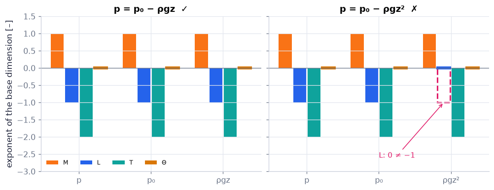

```python
basis = ["M", "L", "T", "Θ"]                                                       # base dimensions
vec = lambda u: ch01.dimension_vector(u)                                           # exponent vector of a unit
terms_ok = {"p": vec("Pa"), "p₀": vec("Pa"), "ρgz": vec("kg/m**3") + vec("m/s**2") + vec("m")}          # correct law
terms_bad = {"p": vec("Pa"), "p₀": vec("Pa"), "ρgz²": vec("kg/m**3") + vec("m/s**2") + 2 * vec("m")}    # wrong law: z²
cols = [COLORS["orange"], COLORS["blue"], COLORS["teal"], COLORS["amber"]]         # M orange, L blue, T teal, Θ amber
fig, axes = plt.subplots(1, 2, figsize=(9, 3.4), sharey=True)                      # left correct, right wrong
for ax, terms, title in ((axes[0], terms_ok, "p = p₀ − ρgz  ✓"), (axes[1], terms_bad, "p = p₀ − ρgz²  ✗")):   # the two panels
    ref = terms["p"]                                                                # the dimension every term must have
    for j, (name, e) in enumerate(terms.items()):                                   # one group of four bars per term
        for b in range(4):                                                          # one bar per base dimension
            bad = e[b] != ref[b]                                                    # this exponent does not match
            x_b = j + (b - 1.5) * 0.2                                               # bar position
            ax.bar(x_b, e[b], width=0.18, color=cols[b], label=basis[b] if j == 0 else None)   # the bar (height = exponent)
            if e[b] == 0:                                                           # a zero exponent has no height …
                ax.plot([x_b - 0.08, x_b + 0.08], [0, 0], color=cols[b], lw=4)      # … so draw a short thick stub instead
            if bad:                                                                 # this exponent differs from p's
                ax.bar(x_b, ref[b], width=0.18, fill=False, edgecolor=COLORS["rose"], lw=2, ls="--")   # where it should be
                ax.annotate(f"{basis[b]}: {e[b]} ≠ {ref[b]}".replace("-", "−"), (x_b, ref[b]), (x_b - 0.9, -2.6),   # label it
                            color=COLORS["rose"], fontsize=10, arrowprops=dict(arrowstyle="->", color=COLORS["rose"]))
    ax.set_xticks(range(3)); ax.set_xticklabels(list(terms)); ax.axhline(0, color=COLORS["muted"], lw=0.8)   # term names, zero line
    ax.set_title(title)                                                             # which formula
axes[0].set_ylim(-3.0, 1.5)                                                         # room for the annotation
axes[0].set_ylabel("exponent of the base dimension [–]")                            # shared y label
axes[0].legend(ncol=4, fontsize=8, loc="lower left")                                # which colour is which dimension
plt.show()                                                                          # display
```

**What you see.** Two panels of grouped bars — the exponents of M (orange), L (blue), T (teal) and Θ (amber) for each term of a formula; an exponent of 0 (Θ everywhere, since no temperature appears) is drawn as a short flat stub. On the left every term has the same pattern (1, −1, −2, 0). On the right the ρgz² term has L exponent 0 where p has −1: its L bar is only a stub, the dashed rose outline shows where it should reach, and the label reads "L: 0 ≠ −1".

**How to read it.** Equal bars for every term mean the formula is dimensionally homogeneous and may be right; one mismatched bar is enough to reject a formula without any experiment.

**What would change if…** Add a term ½ρu² (the dynamic pressure) to the left panel: its bars would match p's too — Bernoulli's equation (Ch. 4) passes this test.

**What would change if…** a problem had seven variables? Checking one equation is easy; finding *all* the unit-free combinations needs bookkeeping. **Next:** put the exponent vectors side by side as the columns of a matrix (C67).

### 🧩 The dimensional matrix: dimensions as columns of numbers `C67`

*The question:* How do we write down what dimensions each variable has, so that linear algebra can reason about them?

#### The problem in plain words

An engineer wants the pressure drop along a pipe for any fluid, diameter, roughness and speed. Seven variables at ten values each would be 10⁷ experiments. Dimensional analysis promises far fewer — and it starts by tabulating dimensions.

#### The idea

Stack the exponent vectors of C64 as columns: the rows are the base dimensions, the columns the variables. Everything dimensional analysis needs is now in one small integer matrix.

📝 **Note.** **Step 1 — choose the variables** `C65` — The most important step: one solution variable (Δp) plus everything it can depend on — geometry (Δx, d, ε), flow (U) and material (ρ, μ). Leave one out and no amount of algebra recovers it (dropping μ is tested in the C69 collapse figure); add unnecessary ones and the result gets weaker.

$$ f(\Delta p, \Delta x, d, \varepsilon, U, \rho, \mu) = 0 \qquad \text{(1.38)} $$

📝 **Note.** **Step 2 — dimensions** `C66` — [q] means "the dimension of q", written with M, L, T and Θ: [U] = L/T, [p] = M/(LT²), [C_p] = L²/(ΘT²). Temperature often appears only as k_BΘ, RΘ or C_pΘ, whose dimension is L²/T², so three base dimensions suffice for most flows. (The kilomole in R_u is treated as a pure number, as the book's Example 1.2 does; `dimension_vector` says so with a warning.)

> 📎 **Primer — matrices, determinants and minors.** `P53` · A matrix is a table of numbers; the **determinant** of a square one is a single number that is zero exactly when its columns are dependent. A **minor** is the determinant of a square piece cut out of a bigger matrix. 3×3 determinants by **cofactor expansion** along the first row: $a_{11}(a_{22}a_{33} - a_{23}a_{32}) - a_{12}(a_{21}a_{33} - a_{23}a_{31}) + a_{13}(a_{21}a_{32} - a_{22}a_{31})$.

```python
print(np.linalg.det(np.array([[2, 0, 0], [0, 3, 0], [0, 0, 4]])))   # a diagonal matrix: det = 2 × 3 × 4 = 24.0
```

```
23.999999999999993
```

> 📎 **Primer — linear independence and rank.** `P54` · Vectors are independent if none is a combination of the others. The **rank** of a matrix is the number of independent columns (which equals the number of independent rows) — the size of its largest nonzero minor.

```python
print(np.linalg.matrix_rank(np.array([[1, 2], [2, 4]])))   # the second column is 2 × the first → rank 1
```

```
1
```

#### The maths, step by step

1. Columns in the order of $f(\Delta p, \Delta x, d, \varepsilon, U, \rho, \mu) = 0$ (1.38): Δp, Δx, d, ε, U, ρ, μ.
2. [Δp] = M L⁻¹ T⁻² → column (1, −1, −2); [Δx] = [d] = [ε] = L → (0, 1, 0); [U] = L T⁻¹ → (0, 1, −1); [ρ] = M L⁻³ → (1, −3, 0); [μ] = M L⁻¹ T⁻¹ → (1, −1, −1).
3. The matrix (no Θ row is needed): $$\begin{array}{c|ccccccc} & \Delta p & \Delta x & d & \varepsilon & U & \rho & \mu\\\hline \mathrm M & 1&0&0&0&0&1&1\\ \mathrm L & -1&1&1&1&1&-3&-1\\ \mathrm T & -2&0&0&0&-1&0&-1\end{array} \qquad (1.39)$$
4. Its rank r is at most 3, because it has three rows.

📝 **Note.** **Step 3 — rank by minors** `C68` — r is the size of the largest square sub-matrix with a nonzero determinant. The minor of the first three columns (Δp, Δx, d) is 0 — Δx and d are both pure lengths, so those columns are dependent — but the minor of the last three (U, ρ, μ) is −1 ≠ 0, so r = 3 (worked by hand below). A rank below the number of rows happens when one row is a combination of the others, for example in statics problems where mass enters only through force.

#### ✏️ Tiny example: the (U, ρ, μ) minor by hand

Rows M, L, T of the columns U, ρ, μ: [[0, 1, 1], [1, −3, −1], [−1, 0, −1]].

Cofactor expansion along row 1: 0·((−3)(−1) − (−1)(0)) − 1·((1)(−1) − (−1)(−1)) + 1·((1)(0) − (−3)(−1)) = 0 − 1·(−1 − 1) + (0 − 3) = 2 − 3 = **−1** ≠ 0 → r = 3.

The first-three-columns minor [[1, 0, 0], [−1, 1, 1], [−2, 0, 0]]: expansion gives 1·(1·0 − 1·0) − 0 + 0 = 0.

> 📎 **Primer — itertools.combinations.** `P55` · `combinations(range(7), 3)` lists every way to choose 3 of 7 column indices, without repeats and ignoring order — 35 of them.

```python
import itertools                                          # standard library: combinatorics
print(len(list(itertools.combinations(range(7), 3))))     # 7·6·5/(3·2·1) = 35 ways to pick 3 columns
```

```
35
```

```python
A, names, rows = ch01.dimensional_matrix(ch01.PIPE)                  # Eq. (1.39): integer matrix, column names, row names
print(rows, names)                                                   # ['M', 'L', 'T'] ['dp', 'dx', 'd', 'eps', 'U', 'rho', 'mu']
print(A)                                                             # the 3 × 7 matrix
r, ri, ci = ch01.rank_by_minors(A)                                   # rank and the first nonzero r × r minor found
print(f"rank {r}; first nonzero minor: rows {ri}, columns {[names[c] for c in ci]}")   # r = 3 and its witness
print("det of (U, ρ, μ):", ch01.minor_determinant(A, (0, 1, 2), (4, 5, 6)))    # −1, exact integer arithmetic
print("det of (Δp, Δx, d):", ch01.minor_determinant(A, (0, 1, 2), (0, 1, 2)))  # 0
```

```
['M', 'L', 'T'] ['dp', 'dx', 'd', 'eps', 'U', 'rho', 'mu']
[[ 1  0  0  0  0  1  1]
 [-1  1  1  1  1 -3 -1]
 [-2  0  0  0 -1  0 -1]]
rank 3; first nonzero minor: rows (0, 1, 2), columns ['dp', 'dx', 'U']
det of (U, ρ, μ): -1
det of (Δp, Δx, d): 0
```

**What does the code above do?**

1. `dimensional_matrix` builds the matrix $\left(\begin{smallmatrix}1&0&0&0&0&1&1\\-1&1&1&1&1&-3&-1\\-2&0&0&0&-1&0&-1\end{smallmatrix}\right)$ (1.39) from the dictionary of variables and units (`ch01.PIPE`), dropping the empty Θ row.
2. `rank_by_minors` searches the minors in order and returns the rank with the first nonzero witness — here the columns (Δp, Δx, U); any nonzero 3×3 minor proves r = 3.
3. `minor_determinant` evaluates a chosen minor exactly by cofactor expansion: −1 for (U, ρ, μ), 0 for (Δp, Δx, d).

> 📎 **Primer — np.linalg.det and np.linalg.matrix_rank.** `P56` · numpy's floating-point versions: `det` returns, for example, −0.9999999999999998 for an integer −1 (round-off), so round it before comparing; `matrix_rank` counts the independent columns but, working in floating point, ignores directions smaller than a tiny tolerance so that round-off is not mistaken for independence.

```python
print(np.linalg.det(A[:, 4:7]), round(np.linalg.det(A[:, 4:7])))   # float round-off, then the exact integer −1
```

```
-1.0000000000000002 -1
```

#### From scratch: every 3×3 minor by cofactor expansion

```python
def det3(M):                                                        # determinant of a 3×3 matrix by cofactor expansion (P53)
    return (M[0][0] * (M[1][1] * M[2][2] - M[1][2] * M[2][1])   # a11 (a22 a33 − a23 a32)
            - M[0][1] * (M[1][0] * M[2][2] - M[1][2] * M[2][0])   # − a12 (a21 a33 − a23 a31)
            + M[0][2] * (M[1][0] * M[2][1] - M[1][1] * M[2][0]))   # + a13 (a21 a32 − a22 a31)
all_c = list(itertools.combinations(range(7), 3))                   # the 35 choices of three columns
nonzero = [c for c in all_c if det3(A[:, c]) != 0]                  # the minors that are not zero
assert len(nonzero) > 0                                             # at least one → rank 3
assert 3 == ch01.rank_by_minors(A)[0] == np.linalg.matrix_rank(A)   # hand, library and numpy agree on r = 3
assert all(det3(A[:, c]) == round(np.linalg.det(A[:, c])) for c in all_c)   # every minor matches numpy
print(f"{len(nonzero)} of {len(all_c)} minors are nonzero; rank = 3")   # how many minors survive
```

```
21 of 35 minors are nonzero; rank = 3
```

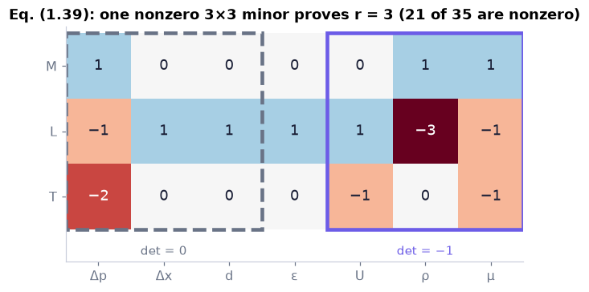

```python
symbols = ["Δp", "Δx", "d", "ε", "U", "ρ", "μ"]                                      # column labels
fig, ax = plt.subplots(figsize=(7.4, 3.2))                                          # one heatmap
ax.imshow(A, cmap="RdBu", vmin=-3, vmax=3)                                          # imshow colours each matrix cell
for i in range(A.shape[0]):                                                         # print the integer in every cell
    for j in range(A.shape[1]):   # every column
        ax.text(j, i, f"{A[i, j]:d}".replace("-", "−"), ha="center", va="center", fontsize=12,   # the integer, with a true minus sign
                color="white" if abs(A[i, j]) >= 2 else COLORS["ink"])             # white text on the dark cells
ax.set_xticks(range(7)); ax.set_xticklabels(symbols); ax.set_yticks(range(3)); ax.set_yticklabels(rows)   # label columns and rows
ax.grid(False)                                                                      # no grid lines over the cells
ax.add_patch(plt.Rectangle((3.5, -0.5), 3, 3, fill=False, ec=COLORS["accent"], lw=3))   # the (U, ρ, μ) minor
ax.text(5, 2.75, "det = −1", color=COLORS["accent"], ha="center", va="top", fontsize=10)   # its determinant
ax.add_patch(plt.Rectangle((-0.5, -0.5), 3, 3, fill=False, ec=COLORS["muted"], lw=3, ls="--"))   # the (Δp, Δx, d) minor
ax.text(1, 2.75, "det = 0", color=COLORS["muted"], ha="center", va="top", fontsize=10)   # its determinant
ax.set_ylim(3.0, -0.6)                                                              # leave room for the labels below
ax.set_title(f"Eq. (1.39): one nonzero 3×3 minor proves r = 3 ({len(nonzero)} of 35 are nonzero)")   # the message
savefig(fig, "ch01", "c67_dimensional_matrix")                                      # keep a copy for review
plt.show()                                                                          # display
```

**What you see.** The 3 × 7 integer matrix $\left(\begin{smallmatrix}1&0&0&0&0&1&1\\-1&1&1&1&1&-3&-1\\-2&0&0&0&-1&0&-1\end{smallmatrix}\right)$ (1.39) as coloured cells, with the (U, ρ, μ) block outlined in purple (determinant −1) and the (Δp, Δx, d) block outlined in grey (determinant 0).

**How to read it.** One nonzero 3×3 block is enough to prove r = 3. The three identical pure-length columns (Δx, d, ε) are what make many minors vanish: any block containing two of them has two equal columns.

**What would change if…** Add the temperature T as an eighth variable and a Θ row appears, so the rank could reach 4 — Example 1.2 (C73) has r = 4.

**What would change if…** we asked which combinations of exponents make a product of the variables dimensionless? That is solving A·k = 0 — the null space of this matrix, and the Π theorem (C69).

### 🧩 Buckingham's Π theorem: a law depends on n − r numbers `C69`

*The question:* Why can seven pipe-flow variables be squeezed into four dimensionless numbers — and why exactly four?

#### The problem in plain words

Wind-tunnel models of aircraft, scale models of harbours, rotating-tank experiments for the atmosphere: a small experiment stands in for a big system when the right dimensionless numbers match. The Reynolds, Froude and Rossby numbers (Ch. 4 §4.11, Ch. 13) all come from this theorem.

#### The idea

A product of powers $q_1^{k_1}\cdots q_n^{k_n}$ is dimensionless exactly when its exponent vector **k** solves A·**k** = 0. The solutions form a subspace — the **null space** — whose dimension is n − r. Each basis vector is one Π group.

```
7 variables  →  matrix of rank 3  →  null space of dimension 7 − 3 = 4  →  Π₁, Π₂, Π₃, Π₄
```

📝 **Note.** **The starting relation** `N22` — The starting point is a relation among the n variables — written in code as the input dictionary of `pi_groups`; Ch. 4 §4.11 starts from the same form.

$$ f(q_1, q_2, \dots, q_n) = 0 \qquad \text{(1.36)} $$

📝 **Note.** **Step 4 — count the groups** `N23` — The number of independent groups is n − r. Pipe: 7 − 3 = 4.

> 📎 **Primer — null space and rank–nullity theorem.** `P58` · The null space of A is the set of all vectors k with A·k = 0 (sums and multiples of solutions are again solutions). **Rank–nullity:** for a matrix with n columns, rank + (dimension of the null space) = n.

```python
print(sp.Matrix([[1, 1, 0], [0, 0, 1]]).nullspace())   # rank 2, 3 columns → one null-space vector: (−1, 1, 0)
```

```
[Matrix([
[-1],
[ 1],
[ 0]])]
```

> 📎 **Primer — scaling the base units.** `P59` · Change the unit of length by a factor λ_L (m → cm: λ_L = 100), of mass by λ_M, of time by λ_T. A quantity with dimension M^a L^b T^c gets its **number** multiplied by λ_M^a λ_L^b λ_T^c; the physical quantity itself is unchanged.

```python
print(1000 * 1000**1 * 100**-3)    # 1000 kg/m³ in g/cm³: λ_M = 1000 (kg → g), λ_L = 100 (m → cm), dimension M L⁻³ → 1.0
```

```
1.0
```

> 📎 **Primer — sympy Matrix and nullspace.** `P61` · `sp.Matrix(...)` keeps integers exact; `.rank()` and `.nullspace()` return exact results — fractions, never round-off.

```python
print(sp.Matrix([[1, 0, 0, 0, 0, 1, 1], [-1, 1, 1, 1, 1, -3, -1], [-2, 0, 0, 0, -1, 0, -1]]).rank())   # (1.39) → 3
```

```
3
```

#### 🧮 Derivation — Buckingham's Π theorem (Eq. 1.37)

**What we want to show.** Show that any correct relation among n dimensional variables can be rewritten as a relation among exactly n − r independent dimensionless groups, with r the rank of the matrix A of dimensions — and see why the groups are not unique.

**Assumptions.** The variable list is complete (step 13: nothing else can enter f) · f is dimensionally homogeneous, i.e. true in every unit system (steps 12–13) · all dimensions are products of powers of the base dimensions (step 2).

**The plan.**

1. A product of powers is dimensionless exactly when its exponent vector solves A·k = 0.
2. Rank–nullity counts the independent solutions: n − r.
3. Choosing the units cleverly shows that the relation can depend only on those groups.

**Tools we use** (each explained before this point): dimensional homogeneity (C64) · the dimensional matrix and its rank (C67, C68) · exponent rules (P43) · linear independence and rank (P54) · null space and rank–nullity (P58) · scaling the base units (P59) · matrices and minors (P53)

**We start from**

$$ f(q_1, q_2, \dots, q_n) = 0 \ \ (1.36), \text{ with dimensional matrix } A \text{ of rank } r $$

*In words:* a complete, dimensionally homogeneous relation among n variables whose dimensions we have tabulated (rows = base dimensions, columns = variables).

**Step 1 of 13 — Form a general product of powers.**

$$ \Pi = q_1^{k_1}\,q_2^{k_2}\cdots q_n^{k_n} $$

- *Why we can do this:* We *look for* unit-free combinations of this single-product (monomial) form, because a product of powers of the variables has a dimension that is again a product of powers of M, L, T, Θ, which we can set to 1. Steps 9–13 show that nothing more general is ever needed. The exponents k = (k₁, …, k_n) are what we must find.
- *In words:* A group is some variables multiplied together, each raised to a power.

**Step 2 of 13 — Write its dimension with the matrix entries.**

$$ [\Pi] = \prod_d d^{\,\sum_j A_{dj} k_j} $$

- *Why we can do this:* [q_j] = M^{A_Mj} L^{A_Lj} T^{A_Tj} Θ^{A_Θj}; raising to k_j multiplies the exponents and multiplying quantities adds them (P43).
- *In words:* The exponent of each base dimension is a weighted sum of the k's.

**Step 3 of 13 — Require every exponent to vanish.**

$$ A\,\mathbf k = \mathbf 0 $$

- *Why we can do this:* Dimensionless means M⁰L⁰T⁰Θ⁰; each row d of A gives one equation Σ_j A_dj k_j = 0.
- *In words:* A group is dimensionless exactly when its exponent vector solves this linear system.

**Step 4 of 13 — Name the solution set.**

$$ \{\mathbf k : A\mathbf k = \mathbf 0\} = \operatorname{null}(A) $$

- *Why we can do this:* Definition of the null space (P58); sums and multiples of solutions are solutions, so it is a vector space.
- *In words:* All dimensionless groups live in the null space of A.

**Step 5 of 13 — Count its dimension.**

$$ \dim\operatorname{null}(A) = n - r $$

- *Why we can do this:* The rank–nullity theorem for a matrix with n columns: rank + nullity = n (P58).
- *In words:* There are exactly n − r independent exponent vectors.

**Step 6 of 13 — Pick a basis and call the groups Π₁ … Π_{n−r}.**

$$ \mathbf k^{(1)},\dots,\mathbf k^{(n-r)} \;\to\; \Pi_1,\dots,\Pi_{n-r} $$

- *Why we can do this:* Any basis of the null space will do; its vectors are linearly independent (P54), so no group is a product of powers of the others (see C71, the note just after this derivation). Different bases give different, equivalent sets — the groups are not unique.
- *In words:* n − r independent dimensionless numbers.

**Step 7 of 13 — Show every group is built from these.**

$$ \mathbf k = \sum_i c_i\mathbf k^{(i)} \;\Rightarrow\; \Pi = \prod_i \Pi_i^{\,c_i} $$

- *Why we can do this:* A basis spans the space; adding exponent vectors multiplies the corresponding powers (P43).
- *In words:* Any other dimensionless combination is a product of powers of Π₁ … Π_{n−r}.

**Step 8 of 13 — Choose r variables with independent columns.**

$$ \det A_{\rm rep} \neq 0 $$

- *Why we can do this:* Rank r means some r×r minor is nonzero (C68); its r variables are the repeating set. If A has more rows than r, drop the dependent rows first.
- *In words:* Pick r variables that between them carry all the independent dimensions.

**Step 9 of 13 — Build one group for each other variable.**

$$ A_{\rm rep}\,\mathbf a_j = -A_{\cdot j}\ \Rightarrow\ \Pi_j = q_j \prod_{i\in\text{rep}} q_i^{\,a_{ji}}\quad (j \notin \text{rep}) $$

- *Why we can do this:* The exponent vector of Π_j has 1 in place j, the unknowns a_j in the repeating places and 0 elsewhere, so A·k = 0 (step 3) becomes the square system A_rep a_j = −A_{·j} (the exponent algebra worked with numbers in C70 below). It has exactly one solution because det A_rep ≠ 0 (step 8). This gives n − r groups; each contains its own q_j and no other non-repeating variable, so their exponent vectors are independent (P54), and n − r independent vectors in a space of dimension n − r (step 5) form a basis of null(A).
- *In words:* Every non-repeating variable, made dimensionless with the repeating ones, is a group — and together they are a basis.

**Step 10 of 13 — Rescale the base units.**

$$ q_j \to q_j\prod_d \lambda_d^{A_{dj}} $$

- *Why we can do this:* Changing the unit of dimension d by a factor λ_d multiplies the *number* of every quantity by λ_d to its exponent (P59); the physics is unchanged.
- *In words:* New units, new numbers, same world.

**Step 11 of 13 — Choose the scales that make the repeating variables equal to 1.**

$$ \sum_d A_{dj}\ln\lambda_d = -\ln q_j \quad (j \in \text{rep}) $$

- *Why we can do this:* Taking logs turns step 10 into r linear equations for the ln λ_d, whose matrix is the (transposed) repeating block — nonsingular by step 8 — so a solution exists.
- *In words:* We can always pick units in which the r repeating variables are exactly one.

**Step 12 of 13 — Read the other variables in those units.**

$$ q_j' = \Pi_j \quad (j \notin \text{rep}) $$

- *Why we can do this:* Π_j = q_j × (powers of the repeating variables) from step 9 is dimensionless, so its number is the same in every unit system (C64); in the new units the repeating factors are 1, so q_j′ equals Π_j.
- *In words:* In these units each remaining variable *is* its group.

**Step 13 of 13 — Use homogeneity to drop the ones.**

$$ f(1,\dots,1,\Pi_1,\dots,\Pi_{n-r}) = 0 \;\Rightarrow\; \phi(\Pi_1,\dots,\Pi_{n-r}) = 0 $$

- *Why we can do this:* A correct law holds in every unit system (C64), in particular in these; the r constant ones are absorbed into a new function φ. Completeness of the variable list guarantees that nothing else hides in f.
- *In words:* The law depends only on the n − r groups.

**Result**

$$ \phi(\Pi_1, \Pi_2, \dots, \Pi_{n-r}) = 0 \quad\text{or}\quad \Pi_1 = \varphi(\Pi_2, \dots, \Pi_{n-r}) $$

*In words:* n variables with r independent dimensions can always be traded for n − r independent dimensionless groups.

**What it means.** Dimensional analysis is linear algebra: groups are null-space vectors, their number is rank–nullity, and a different repeating set is a change of basis. It is why experiments are plotted against Re, Fr and Ro, and why a small model can stand for a big system (Ch. 4 §4.11). It fails — silently — if a relevant variable is missing (drop μ from the pipe: 3 groups, no Reynolds number, and laminar data will not collapse) or if the "law" mixes quantities that are only numerically related in one unit system. In the explainer `buckingham_pi_machine` below, switch the units to cgs and every Π value stays put.

**Check it.** Pipe: n = 7, r = 3 → 4 groups, $\Delta p/\rho U^2 = \varphi(\Delta x/d,\ \varepsilon/d,\ \mu/\rho U d)$ (1.40) ✓; Π₁ = Δp/ρU² = 10 in SI and in cgs ✓ (code below); `groups_independent` rejects a fifth group ✓; Example 1.4 (n = 4, r = 3) → one group, hence a constant ✓. The sympy cell checks the null space exactly.

```python
import sympy as sp                                            # exact linear algebra (primer P61)
A_s = sp.Matrix([[1, 0, 0, 0, 0, 1, 1],                       # M row of (1.39): columns dp dx d eps U rho mu
                 [-1, 1, 1, 1, 1, -3, -1],                    # L row
                 [-2, 0, 0, 0, -1, 0, -1]])                   # T row
ns = A_s.nullspace()                                          # a basis of all dimensionless exponent vectors (step 4)
print(A_s.rank(), len(ns), A_s.shape[1] - A_s.rank())         # 3 4 4 → rank–nullity (step 5)
print(all((A_s * k).is_zero_matrix for k in ns))              # True → every basis vector is dimensionless (step 3)
k1 = sp.Matrix([1, 0, 0, 0, -2, -1, 0])                       # exponents of Π₁ = Δp U⁻² ρ⁻¹
print((A_s * k1).is_zero_matrix)                              # True → Π₁ is dimensionless
print(sp.Matrix.hstack(*ns, k1).rank() == len(ns))            # True → Π₁ is a combination of the basis (step 7)
rep = [4, 2, 5]                                               # step 8: repeating columns U, d, rho (their minor is nonzero)
A_rep = A_s[:, rep]                                           # the 3×3 repeating block
print(A_rep.det() != 0)                                       # True → step 9's systems have unique solutions
groups_k = []                                                 # exponent vectors built as in step 9
for j in (0, 1, 3, 6):                                        # the non-repeating columns dp, dx, eps, mu
    a_j = A_rep.LUsolve(-A_s[:, j])                           # solve A_rep a_j = −A_{·j} exactly
    k = sp.zeros(7, 1); k[j] = 1                              # 1 in the variable's own place …
    for i, col in enumerate(rep):                             # … and the solved exponents in the repeating places
        k[col] = a_j[i]                                        # exponent of repeating variable col
    groups_k.append(k)                                        # keep this group's exponent vector
print(all((A_s * k).is_zero_matrix for k in groups_k), sp.Matrix.hstack(*groups_k).rank())   # True 4 → a basis of null(A)
```

```
3 4 4
True
True
True
True
True 4
```

> ⚠️ **Common confusion (traps in this derivation):** believing the groups are unique; forgetting that the relation must be complete and homogeneous; choosing a singular repeating set (two pure lengths such as d and ε cannot cancel time).

📝 **Note.** **Step 5 — build the groups (exponent algebra)** `C70` — Choose r = 3 repeating variables whose minor is nonzero (U, d, ρ). Each group is one other variable times powers of them. For Δp: Π₁ = Δp U^a d^b ρ^c; matching M: c + 1 = 0; L: a + b − 3c − 1 = 0; T: −a − 2 = 0 gives a = −2, b = 0, c = −1 (stated; solved in code below). The same with Δx, ε and μ gives:

$$ \Pi_1 = \frac{\Delta p}{\rho U^2},\quad \Pi_2 = \frac{\Delta x}{d},\quad \Pi_3 = \frac{\varepsilon}{d},\quad \Pi_4 = \frac{\mu}{\rho U d} $$

📝 **Note.** **Groups by inspection** `N24` — The same groups can be found **by inspection**, cancelling M, L and T one ratio at a time — the way Navier–Stokes is made dimensionless in Ch. 4 §4.11.

📝 **Note.** **Combining groups** `C71` — Products and powers of groups are groups too: Δp d²ρ/μ² = Π₁/Π₄² and ε/Δx = Π₃/Π₂. Any such set may replace the original, but **only n − r of them are independent** — a fifth is always a combination of four (`groups_independent` → False, below).

📝 **Note.** **Step 6 — the dimensionless law** `C72` — Π₄ is the inverse of the Reynolds number, 1/Re.

$$ \frac{\Delta p}{\rho U^2} = \varphi\!\left(\frac{\Delta x}{d}, \frac{\varepsilon}{d}, \frac{\mu}{\rho U d}\right) \qquad \text{(1.40)} $$

📝 **Note.** **Step 7 — add physics** `N25` — Far from the inlet the pressure drop is proportional to the length, so Δp/ρU² = (Δx/d)·φ₂(ε/d, Re): three numbers become two. For slow laminar flow in a smooth pipe the full solution (Ch. 8) gives φ₂ = 32/Re — the line the collapse figure below follows.

#### ✏️ Tiny example: Π₁ in two unit systems

- SI: Δp = 100 Pa, ρ = 1000 kg/m³, U = 0.1 m/s → Π₁ = 100/(1000 × 0.01) = 10.
- cgs: Δp = 1000 dyn/cm², ρ = 1 g/cm³, U = 10 cm/s → Π₁ = 1000/(1 × 100) = 10.
- With d = 1 cm and μ = 10⁻³ Pa s: Π₄ = 10⁻³/(1000 × 0.1 × 0.01) = 10⁻³, i.e. Re = 1000.

> 📎 **Primer — fractions.Fraction.** `P60` · `Fraction(-1, 2)` is an exact rational number; fluidpy returns exponents this way so that ½ never becomes 0.49999.

```python
from fractions import Fraction              # exact rational numbers (standard library)
print(Fraction(1, 3) + Fraction(1, 6))      # → 1/2 exactly
```

```
1/2
```

```python
groups = ch01.pi_groups(ch01.PIPE, solution="dp", repeating=("U", "d", "rho"))   # (1.40): n − r = 4 groups, Δp in the first
print([ch01.group_latex(g) for g in groups])                                     # their LaTeX forms
print(ch01.solve_exponents("dp", ("U", "d", "rho"), ch01.PIPE))                  # C70: exponents of Π₁ as exact fractions
pipe_vals = {"dp": 100.0, "dx": 1.0, "d": 0.01, "eps": 1e-5, "U": 0.1, "rho": 1000.0, "mu": 1e-3}   # one pipe state in SI
for system in ("SI", "cgs", "imperial"):                                         # the same state in three unit systems
    nums = ch01.rescale_units(pipe_vals, ch01.PIPE, system)                      # new numbers for the same physics
    print(system, [round(ch01.group_value(g, nums), 6) for g in groups])        # [10.0, 100.0, 0.001, 0.001] each time
extra = {"dp": 1, "d": 2, "rho": 1, "mu": -2}                                    # C71: Δp d² ρ / μ² = Π₁/Π₄²
print("four groups independent:", ch01.groups_independent(groups))              # True
print("with a fifth group:", ch01.groups_independent(groups + [extra]))         # False: only n − r are independent
```

```
['\\frac{\\Delta p}{U^{2} \\rho}', '\\frac{\\Delta x}{d}', '\\frac{\\varepsilon}{d}', '\\frac{\\mu}{U d \\rho}']
{'dp': Fraction(1, 1), 'U': Fraction(-2, 1), 'd': Fraction(0, 1), 'rho': Fraction(-1, 1)}
SI [10.0, 100.0, 0.001, 0.001]
cgs [10.0, 100.0, 0.001, 0.001]
imperial [10.0, 100.0, 0.001, 0.001]
four groups independent: True
with a fifth group: False
```

**What does the code above do?**

1. `pi_groups` finds a basis of the null space with the chosen repeating variables; `group_latex` prints each group.
2. `solve_exponents` solves the 3×3 exponent system of C70 exactly.
3. `rescale_units` + `group_value`: every group keeps its value in SI, cgs and imperial units.
4. `groups_independent` checks the rank of the groups' exponent matrix: four are independent, a fifth never is.

> 📎 **Primer — np.linalg.solve.** `P57` · `np.linalg.solve(B, b)` finds the vector x with B·x = b for a square, nonsingular matrix B.

```python
print(np.linalg.solve(np.array([[2.0, 0.0], [0.0, 4.0]]), np.array([2.0, 8.0])))   # 2x = 2, 4y = 8 → [1. 2.]
```

```
[1. 2.]
```

#### From scratch: the exponent system of Π₁ with numpy

```python
B = A[:, [names.index(k) for k in ("U", "d", "rho")]]         # columns of the repeating variables (a nonsingular minor)
b = -A[:, names.index("dp")]                                  # move the Δp column (exponent 1) to the right-hand side
x = np.linalg.solve(B.astype(float), b.astype(float))         # exponents a, b, c of U, d, ρ (P57)
assert np.allclose(x, [-2, 0, -1])                            # Π₁ = Δp U⁻² d⁰ ρ⁻¹
lib = ch01.solve_exponents("dp", ("U", "d", "rho"), ch01.PIPE)   # the library's exact exponents
assert np.allclose(x, [float(lib[k]) for k in ("U", "d", "rho")])   # same as the library's exact fractions
print("exponents of U, d, ρ in Π₁:", x)   # [−2, 0, −1]
```

```
exponents of U, d, ρ in Π₁: [-2.  0. -1.]
```

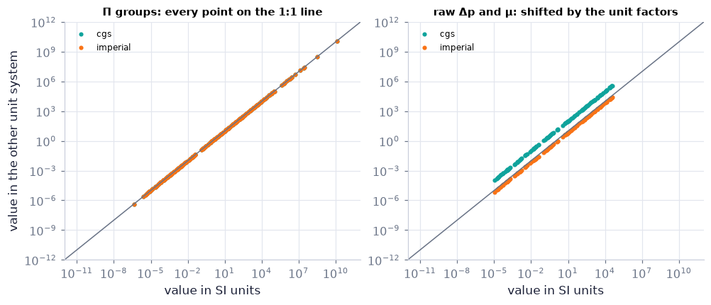

```python
rng_p = np.random.default_rng(7)                                                  # seeded pipe states (P10)
lo_hi = {"dp": (1, 1e5), "dx": (0.1, 100), "d": (1e-3, 1), "eps": (1e-6, 1e-3), "U": (1e-3, 10), "rho": (1, 1e3), "mu": (1e-5, 1)}  # SI ranges
states = [{k: 10**rng_p.uniform(np.log10(a), np.log10(b_)) for k, (a, b_) in lo_hi.items()} for _ in range(60)]  # log-uniform
fig, (axg, axr) = plt.subplots(1, 2, figsize=(9, 3.8))                            # left: groups, right: raw variables
for system, col in (("cgs", COLORS["teal"]), ("imperial", COLORS["orange"])):     # two other unit systems
    xs_g, ys_g, xs_r, ys_r = [], [], [], []                                       # collected points
    for s in states:                                                              # every random pipe state
        new = ch01.rescale_units(s, ch01.PIPE, system)                            # the same state in other units
        xs_g += [ch01.group_value(g, s) for g in groups]; ys_g += [ch01.group_value(g, new) for g in groups]   # Π in SI vs other
        xs_r += [s["dp"], s["mu"]]; ys_r += [new["dp"], new["mu"]]                # two raw variables for contrast
    axg.loglog(xs_g, ys_g, "o", ms=3, color=col, label=system)                    # groups
    axr.loglog(xs_r, ys_r, "o", ms=3, color=col, label=system)                    # raw numbers
for ax, title in ((axg, "Π groups: every point on the 1:1 line"), (axr, "raw Δp and μ: shifted by the unit factors")):   # both panels
    lim = [1e-12, 1e12]; ax.plot(lim, lim, color=COLORS["muted"], lw=1); ax.set_xlim(lim); ax.set_ylim(lim)   # 1:1 line, same range
    ax.set_xlabel("value in SI units"); ax.set_title(title, fontsize=10); ax.legend(fontsize=8)              # labels
axg.set_ylabel("value in the other unit system")                                  # shared meaning of y
plt.show()                                                                        # display
```

**What you see.** Left: the four Π groups of 60 random pipe states, recomputed in cgs (teal) and imperial units (orange), all exactly on the 1:1 line. Right: the raw numbers for Δp and μ of the same states, lying on lines parallel to the diagonal but shifted away from it.

**How to read it.** A group's value does not depend on the units; a dimensional variable's number does (by the factor λ_M^a λ_L^b λ_T^c of P59). That invariance is what step 12 of D28 uses.

**What would change if…** Plot a combination that is *not* dimensionless, such as Δp/(ρU): its points would leave the diagonal by the length-unit factor, like the raw variables on the right.

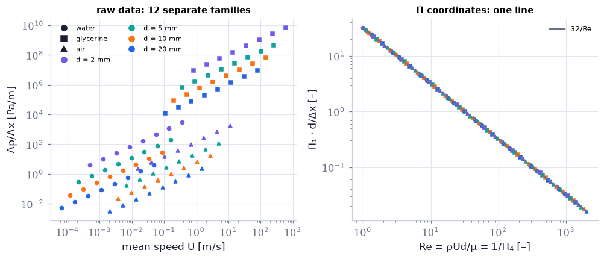

```python
fig, (ax_raw, ax_pi) = plt.subplots(1, 2, figsize=(9, 3.8))                        # left raw data, right Π coordinates
dx_p = 1.0                                                                          # pipe length [m]
fam = 0                                                                             # family counter, to stagger the Re values
for name, mk in (("water", "o"), ("glycerine", "s"), ("air", "^")):                # three fluids
    fp = ch01.FLUIDS[name]                                                          # ρ [kg/m³], μ [Pa s] from fluidpy's property table
    for d_p, col in zip((2e-3, 5e-3, 1e-2, 2e-2), (COLORS["accent"], COLORS["teal"], COLORS["orange"], COLORS["blue"])):   # four diameters [m]
        Re = np.logspace(0.2, np.log10(2000) - 0.24, 8) * 10**(0.04 * fam - 0.2)     # laminar Reynolds numbers 1 … 2000, staggered
        fam += 1                                                                    # next family gets slightly larger Re
        U_p = Re * fp["mu"] / (fp["rho"] * d_p)                                     # the speeds that give them [m/s]
        dp_p = ch01.poiseuille_pressure_drop(fp["mu"], U_p, dx_p, d_p)              # laminar Δp (result derived in Ch. 8; data generator only)
        ax_raw.loglog(U_p, dp_p / dx_p, mk, ms=4, color=col)                        # raw: pressure gradient vs speed
        ax_pi.loglog(Re, dp_p / (fp["rho"] * U_p**2) * d_p / dx_p, mk, ms=4, color=col)   # Π₁ · d/Δx vs Re
Re_line = np.logspace(0, np.log10(2000), 50)   # Reynolds numbers for the reference line
ax_pi.loglog(Re_line, 32 / Re_line, color=COLORS["muted"], lw=1.5, label="32/Re")  # the laminar law
ax_raw.set_xlabel("mean speed U [m/s]"); ax_raw.set_ylabel("Δp/Δx [Pa/m]")   # raw axes with units
ax_raw.set_title("raw data: 12 separate families", fontsize=10)   # left message
ax_pi.set_xlabel("Re = ρUd/μ = 1/Π₄ [–]"); ax_pi.set_ylabel("Π₁ · d/Δx [–]")   # dimensionless axes
ax_pi.set_title("Π coordinates: one line", fontsize=10)   # right message
from matplotlib.lines import Line2D                                                 # simple legend handles
handles = [Line2D([], [], ls="", marker=m, color=COLORS["ink"], label=n) for n, m in (("water", "o"), ("glycerine", "s"), ("air", "^"))]   # marker = fluid
handles += [Line2D([], [], ls="", marker="o", color=c, label=f"d = {d*1e3:g} mm")     # colour = diameter
            for d, c in zip((2e-3, 5e-3, 1e-2, 2e-2), (COLORS["accent"], COLORS["teal"], COLORS["orange"], COLORS["blue"]))]
ax_raw.legend(handles=handles, fontsize=7.5, ncol=2, loc="upper left")              # marker = fluid, colour = diameter
ax_pi.legend(fontsize=8)                                                            # the 32/Re line
savefig(fig, "ch01", "c69_collapse")                                                # keep a copy for review
plt.show()                                                                          # display
```

**What you see.** Left: pressure gradient against speed for water (circles), glycerine (squares) and air (triangles) in four pipe diameters (colours) — twelve families spread over many decades. Right: the same 96 points in Π coordinates, all lying on one grey line.

**How to read it.** Once plotted as Π₁·d/Δx against Re, the data depend on a single number — why engineers plot friction factors against the Reynolds number. Without μ the only groups left would be Δx/d and ε/d, which are the same for every point in one pipe, so nothing could collapse the spread of Π₁: leaving out a variable is fatal (C65).

**What would change if…** Turbulent data from rough pipes would spread out again by ε/d — then Π₃ matters, and one line becomes a family of curves (the Moody chart).

📝 **Note.** **Example 1.2 — the scale height from dimensions alone (stated)** `C73` — Variables H, T₀, M_w, g, R_u (n = 5); M, L, T and Θ all appear and r = 4, so there is one group, HgM_w/(R_uT₀) — and a lone group must be a constant: H = const · R_uT₀/(gM_w). The isothermal atmosphere (C63) fixes the constant to 1; our numbers at 250 K give 7.32 km both ways (code below).

📝 **Note.** **Example 1.3 — Pythagoras** `C74` — Even Pythagoras follows: a right triangle's area is C²φ(β) for hypotenuse C and angle β, and the two smaller similar triangles (*gloss:* same angles, sides in one ratio) add up to it, giving A² + B² = C² (φ(β) = ¼ sin 2β as a check) — a curiosity, not used later.

📝 **Note.** **Example 1.4 — the energy of a blast wave (stated)** `C75` — G. I. Taylor estimated an explosion's energy from photographs: E, ρ, the front radius D and the time t give r = 3 and one group, so E = KρD⁵/t² and D ∝ t^(2/5). K comes only from the full similarity solution (*gloss:* a solution whose shape stays the same as it grows): K ≈ 0.86 for a **free spherical** blast in air (γ = 1.4). Our number: a front of radius 100 m after 25 ms in air of 1.2 kg/m³ gives E = 1.9×10¹³ K J ≈ 4.6K kilotons of TNT. A blast at the ground spreads as a hemisphere, which behaves like half of a free sphere of energy 2E — so the same photograph then means half that energy.

📝 **Note.** **Example 1.5 — why the sky is blue (stated)** `C76` — Scattered intensity S from a small particle of volume V at distance d, for light of wavelength λ (*gloss:* the colour of light; its intensity grows with the square of the wave amplitude). Only L and the intensity dimension appear (the T row is −3 times the M row, so r = 2); energy spreading forces d⁻², the dipole physics forces V², and then the groups force λ⁻⁴. Blue light (450 nm) scatters (700/450)⁴ = 5.9 times more than red (700 nm).

$$ \frac{S}{I} = \frac{V^2}{d^2\lambda^4}\,\varphi_3(n_s) $$

```python
import warnings                                                                      # standard library
with warnings.catch_warnings():                                                      # fluidpy warns that the kmol is treated as a
    warnings.simplefilter("ignore", UserWarning)                                     #   pure number (C66) — expected here
    r_sh = ch01.rank_by_minors(ch01.dimensional_matrix(ch01.SCALE_HEIGHT)[0])[0]     # C73: rank of the scale-height matrix
    g_sh = [ch01.group_latex(g) for g in ch01.pi_groups(ch01.SCALE_HEIGHT)]          # its single group
print("C73: r =", r_sh, "| group:", g_sh)   # rank 4, one group
print(f"C73: R_u T/(g M_w) = {ch01.R_U*250/(ch01.G0*ch01.M_W_AIR):.1f} m; scale_height(250 K) = {ch01.scale_height(250.0):.1f} m")   # dimensional estimate = scale height
print(f"C74: φ(30°) = {ch01.pythagoras_phi(np.radians(30)):.4f}; ¼ sin 60° = {0.25*np.sin(np.radians(60)):.4f}")   # area function check
E_over_K = ch01.blast_energy(100.0, 0.025, 1.2)                                      # C75: E/K for D = 100 m at t = 25 ms [J]
print(f"C75: E = {E_over_K:.2e} K J = {E_over_K/4.184e12:.2f} K kt of TNT; free-sphere K = {ch01.TAYLOR_K_GAMMA14}")   # energy per unit K
ratio = ch01.rayleigh_scattering_ratio(1, 1, 450e-9) / ch01.rayleigh_scattering_ratio(1, 1, 700e-9)   # C76: blue/red
print(f"C76: blue/red scattering = {ratio:.3f}; rank of the Rayleigh matrix = {ch01.rank_by_minors(ch01.dimensional_matrix(ch01.RAYLEIGH)[0])[0]}")   # λ⁻⁴ law
```

```
C73: r = 4 | group: ['\\frac{H M_w g}{R_u T_0}']
C73: R_u T/(g M_w) = 7317.9 m; scale_height(250 K) = 7317.9 m
C74: φ(30°) = 0.2165; ¼ sin 60° = 0.2165
C75: E = 1.92e+13 K J = 4.59 K kt of TNT; free-sphere K = 0.856
C76: blue/red scattering = 5.855; rank of the Rayleigh matrix = 2
```

**What does the code above do?**

1. `dimensional_matrix` and `rank_by_minors` for Example 1.2 give r = 4 and one group; the dimensional estimate R_uT/(gM_w) equals `scale_height` exactly.
2. `pythagoras_phi` is the area function of Example 1.3.
3. `blast_energy` evaluates E = KρD⁵/t² with K = 1 (so the output is "per unit K"); `TAYLOR_K_GAMMA14` is Taylor's constant for a free spherical blast.
4. `rayleigh_scattering_ratio` gives the λ⁻⁴ law's blue-to-red ratio, and the Rayleigh matrix has rank 2.

#### 🎮 Interactive: Why can 7 pipe variables shrink to 4 numbers?

Toggling variables, swapping the repeating set and switching units changes the matrix, its rank and the groups at once — you experiment with the method instead of watching it done once. Its Derivation tab walks through D28.

**What to try:**

- Choose the repeating set (d, ε, ρ) and read why the machine refuses.
- Remove μ: how many groups are left, and which physics is lost?
- Switch to the blast preset: what power of t does the radius follow?
- Change SI → imperial and watch every Π value stay put.

```python
show_viz("ch01", "buckingham_pi_machine")   # full-width explainer; ⤢ Full screen for more room
```

🎮 Interactive 5/5 Why can 7 pipe variables shrink to 4 numbers? Open alone ↗

[interactive chart not shown]

**What would change if…** the problem included rotation (the Earth's rotation rate Ω) as an eighth variable? One more column, the same rank, one more group — the Rossby number of Ch. 13.

*↪ The chapter's 30 exercises are in the book and are not reproduced here. Of the derivations the book leaves to Exercises 1.10, 1.11, 1.13 and 1.14, D14 (isentropic law), D18 (parcel equation) and D19 (adiabatic lapse rate) are written out above; the result of Exercise 1.10 (e = e(T) for a perfect gas) is stated in the C40 block. `S01`*

*↪ The book's reading list is at the end of the printed chapter; the public data used here (CODATA, USSA-1976, IAPWS, Jennings, Taylor) are cited in reference/ch01/SOURCES.md. `S02`*

## ✅ What should have clicked

- A density 'at a point' is the plateau of box averages between molecular noise and the flow's own variation (C06).
- Viscosity is momentum diffusion: τ = μ du/dy, and ν = μ/ρ sets how fast motion spreads (C12).
- In still fluid pressure falls with height at exactly ρg per metre; buoyancy is the resulting face-pressure difference (C20).
- Heat plus work changes internal energy; q and w depend on the route, Δe does not (C25).
- Entropy is the route-independent sum of dq/T, and the Gibbs relations tie state functions together for any process (C35).
- The speed of sound is √((∂p/∂ρ)_s); an incompressible fluid has c → ∞ (C36).
- p = ρRT is the molecular gas law per unit mass, with R = R_u/M_w (C40).
- With no heat and no friction a perfect gas follows p ∝ ρ^γ (C45).
- A displaced parcel obeys ζ″ + N²ζ = 0 (C50).
- N² > 0 oscillates, N² = 0 stays, N² < 0 runs away (C51).
- Air is stable when it cools more slowly than 9.8 K/km: dT/dz > −9.8 K/km (Kundu) ⇔ Γ_met < +9.8 K/km (meteorology) (C54).
- Potential temperature removes adiabatic cooling; stability is θ increasing upward, N² = (g/θ)dθ/dz (C55).
- Every term of a correct law has the same dimensions (C64).
- The dimensions of all variables form an integer matrix whose rank counts the independent dimensions (C67).
- Dimensionless groups are the null space of that matrix: there are n − r of them (C69).

**What later chapters build on**

- Ch. 2–3: fields and fluid particles on the continuum
- Ch. 4: the tensor viscosity law, the energy equation, Boussinesq (α), dimensionless Navier–Stokes (Π)
- Ch. 7 and 13: N² for internal waves; θ and hydrostatics for geophysical fluid dynamics
- Ch. 8: the Couette start-up and Poiseuille results used here as checks
- Ch. 15: the speed of sound and the isentropic relations

**Not taught here (and where to find it)**

- the 30 exercises (in the book)
- moist thermodynamics: saturated adiabats and equivalent potential temperature (beyond Ch. 1)
- the proof of the speed-of-sound formula $c^2 = (\partial p/\partial\rho)_s$ (1.19) (Ch. 15 §15.2)

← All chapters

← PreviousNext →

Code and explanations: shammun/fluidpy (MIT). The book is not reproduced here; equations are cited by number.